# Dissertação de Mestrado

[output not shown]

# **Introdução**

A última geração de modelos de inteligência artificial, que ganhou visibilidade pública a partir do lançamento do ChatGPT 3.5, em novembro de 2022, ampliou, de forma inédita, a capacidade de automatizar ou complementar tarefas cognitivas. Diferentemente de ondas anteriores de automação, em que o alcance se concentrava em atividades manuais e rotineiras, os modelos de linguagem de grande escala (*Large Language Models*, LLMs) atingem ocupações de escritório, finanças, educação, tecnologia e gestão. Nos Estados Unidos, estima-se que 32,1% dos trabalhadores já integravam ferramentas de IA em suas rotinas até o final de 2024, num ritmo de adoção comparável ao do computador pessoal na década de 1980 e superior, em termos populacionais, ao da própria internet ([Bick; Blandin; Deming, 2024](https://doi.org/10.20955/wp.2024.027)). Essa combinação de alcance ocupacional e velocidade de difusão justifica tratar essa nova geração de modelos de inteligência artificial como um problema econômico, e não apenas tecnológico. A maneira que essa tecnologia se espalha por ocupações, seus efeitos potenciais sobre emprego, salários e desigualdade passam a ser uma questão central para a economia do trabalho.

A literatura internacional avançou em duas frentes. De um lado, consolidou-se uma metodologia de construção de índices de exposição baseados em tarefas, a partir do *GPT Exposure* de Eloundou *et al.* (2023), que passou a usar os próprios LLMs como avaliadores das tarefas. De outro, começou a se acumular evidência empírica sobre emprego e salários, com estudos recentes nos Estados Unidos e no Reino Unido convergindo para a conclusão de que o impacto da IA está se manifestando principalmente pela porta de entrada do mercado de trabalho, com recém-formados e trabalhadores jovens em ocupações expostas recebendo salários menores e enfrentando menor oferta de trabalho ([Brynjolfsson; Chandar; Chen, 2025](https://digitaleconomy.stanford.edu/publication/canaries-in-the-coal-mine-six-facts-about-the-recent-employment-effects-of-artificial-intelligence/); [Hosseini Maasoum; Lichtinger, 2025](https://papers.ssrn.com/sol3/papers.cfm?abstract_id=5425555); [Klein Teeselink, 2025](https://papers.ssrn.com/sol3/papers.cfm?abstract_id=5516798)). Essa evidência, no entanto, foi produzida quase inteiramente em economias de alta renda. Permanece uma lacuna importante quando o objeto é um país de renda média, com elevada informalidade, desigualdade racial e regional acentuada e uma estrutura ocupacional distinta da dos países desenvolvidos. É nessa lacuna que o Brasil se encaixa, e é ela que esta dissertação procura ajudar a preencher.

O objetivo desta dissertação é construir e aplicar uma medida de exposição ocupacional à inteligência artificial para o Brasil e investigar se ocupações mais expostas apresentaram mudanças diferenciais nos fluxos e nos salários do emprego formal após a difusão do ChatGPT. Para isso, o trabalho responde a duas perguntas: (i) quais trabalhadores e ocupações estão mais expostos à IA no Brasil? e (ii) ocupações formais mais expostas apresentaram mudanças diferenciais em admissões, desligamentos e salários após a difusão do ChatGPT? A primeira pergunta tem caráter descritivo e distributivo; a segunda, caráter empírico e exploratório sobre a dinâmica do emprego formal.

Para responder a essas perguntas, recorro a duas bases de dados com papéis distintos. A Pesquisa Nacional por Amostra de Domicílios Contínua (PNADc) sustenta a etapa descritiva: por sua representatividade e riqueza de variáveis sociodemográficas, ela permite traçar um retrato de quem está exposto à IA no Brasil. O Cadastro Geral de Empregados e Desempregados (CAGED), por sua vez, sustenta a etapa empírica: como registro administrativo de cobertura plena do mercado formal, ele permite observar admissões, desligamentos e salários no tempo, viabilizando um desenho de diferenças em diferenças em torno do lançamento do ChatGPT. A PNAD responde quem está exposto; o CAGED, o que aconteceu com o emprego formal mais exposto.

A peça que conecta as duas etapas é o índice de exposição. Adotei o *ILO Global Index* (Gmyrek *et al.*, 2025) por dois motivos: ele é o único entre os principais índices estruturado em torno da ISCO-08, classificação internacional com maior compatibilidade com as taxonomias ocupacionais brasileiras, e é o de construção metodologicamente mais robusta, por combinar validação humana de tarefas com classificação assistida por LLMs. Aplicá-lo ao Brasil, no entanto, exigiu uma etapa de tradução: construí um *crosswalk* entre as classificações ocupacionais brasileiras (a COD, usada na PNAD, e a CBO, usada no CAGED) e a ISCO-08.

Antes de apresentar os primeiros achados do estudo, é importante deixar claro o que significa exposição ocupacional, que mede o potencial de a IA afetar as tarefas de uma ocupação. Uma ocupação está mais exposta quando uma parcela relevante de suas tarefas pode ser automatizada ou complementada por modelos de IA. Exposição não é impacto e não é um indicador de substituição. Vamos explorar essa distinção com mais profundidade na seção 2.

Os resultados descritivos, obtidos ao cruzar a PNADc do 3º trimestre de 2025 com o índice da OIT, cobrem 97,8 milhões de trabalhadores e mostram que 10,1% da força de trabalho está em ocupações altamente expostas. Essa exposição não se distribui de forma neutra: concentra-se entre trabalhadores de apoio administrativo, mulheres, brancos, jovens e indivíduos com maior escolaridade, padrões consistentes com o que a OIT observa em países de renda média-alta. A formalidade reforça esse recorte: embora a força de trabalho informal seja maior do que a formal, são os trabalhadores com vínculo formal que se concentram nas ocupações de alta exposição (14,8%, contra 6,7% dos informais). Esse ponto é central para a estratégia empírica da dissertação, pois indica que a corte mais sujeita aos efeitos da IA está justamente no mercado formal, onde o CAGED tem cobertura plena.

Na etapa empírica, segui a abordagem de [Brynjolfsson, Chandar e Chen (2025)](https://digitaleconomy.stanford.edu/publication/canaries-in-the-coal-mine-six-facts-about-the-recent-employment-effects-of-artificial-intelligence/), com um desenho de diferenças em diferenças aplicado ao CAGED, usando o lançamento do ChatGPT como evento e o índice da OIT como fonte de variação no tratamento. Os resultados não apontam um choque generalizado de emprego: no agregado nacional, as admissões, os desligamentos e os salários reais de admissão apresentam coeficientes negativos, porém pequenos e estatisticamente não significativos, e os testes de tendências paralelas são rejeitados para os fluxos, o que limita a interpretação causal. O sinal mais consistente está no salário de entrada, que fica abaixo do das ocupações não expostas, ainda que sem significância robusta. Os ajustes só ganham nitidez quando a análise se desloca para grupos específicos: a retração das admissões é mais forte entre mulheres e trabalhadores com ensino superior, e a queda dos desligamentos é o resultado mais recorrente, aparecendo entre trabalhadores negros, na faixa de 25 a 34 anos, no ensino superior e nas ocupações de renda intermediária. Como admissões e desligamentos recuam ao mesmo tempo, o padrão é compatível com menor movimentação dos fluxos, e não com destruição de vínculos. No conjunto, os achados sugerem, como hipótese, uma acomodação silenciosa do emprego formal nas ocupações mais expostas após o ChatGPT, mas o desenho não observa a adoção efetiva da IA nem o estoque de emprego, e boa parte das estimativas permanece exploratória.

Esta dissertação contribui para a literatura em três dimensões. A primeira é de mensuração: adapto o índice de exposição da OIT ao Brasil, construindo uma correspondência entre classificações ocupacionais internacionais e brasileiras. A segunda é distributiva: mostro quem está mais exposto à IA no mercado de trabalho brasileiro, considerando ocupações, setores, regiões e características sociodemográficas. A terceira é empírica: apresento evidência inicial, a partir dos microdados do CAGED, sobre a dinâmica das admissões, dos desligamentos e dos salários de entrada nas ocupações formais mais expostas após o lançamento do ChatGPT, com atenção às heterogeneidades por sexo, raça, idade, escolaridade e renda.

O restante do trabalho está organizado da seguinte forma. A Seção 2 introduz a teoria e a metodologia dos índices de exposição à IA e justifica a escolha do *ILO Global Index*. A Seção 3 descreve a construção da base analítica com a PNADc e apresenta os resultados descritivos sobre a distribuição da exposição no Brasil. A Seção 4 apresenta a estratégia empírica com o CAGED, detalhando a construção do painel ocupação-mês, o crosswalk entre a CBO e o índice da OIT, a especificação de diferenças em diferenças e o desenho das heterogeneidades. A Seção 5 reúne os resultados, começando pelo efeito médio nacional, passando pelas heterogeneidades por sexo, raça, idade, escolaridade e renda, e encerrando com os casos ocupacionais e as trajetórias por idade.

# 2 Mensuração da exposição ocupacional à IA

## 2.1 Definição e interpretação da exposição ocupacional

Antes de discutir como medir, é preciso definir o que está sendo medindo. O debate público sobre mercado de trabalho mistura com frequência três coisas distintas, e tratá-las como sinônimos leva a interpretações equivocadas. Por isso, começo separando os conceitos e fixando uma definição explícita de exposição que será usada ao longo de todo o trabalho.

Nesta dissertação, defino *exposição ocupacional* como o potencial de uma ocupação ser afetada pela IA, dado o conjunto de tarefas que a compõem. Uma ocupação é mais exposta quando uma parcela relevante de suas tarefas pode ser automatizada ou complementada por modelos de IA. A exposição é, portanto, uma medida de potencial técnico, e não um diagnóstico do que já aconteceu no mercado.

É importante separar a exposição de outros dois conceitos com os quais ela costuma ser confundida. A *adoção efetiva* da tecnologia depende de empresas, trabalhadores, custos, infraestrutura digital, regulação, incentivos e da capacidade de reorganizar processos produtivos; uma ocupação pode ser altamente exposta e mesmo assim ter adoção baixa. Os *efeitos sobre emprego e salários*, por sua vez, só podem ser identificados empiricamente depois que a tecnologia começa a se difundir. Em resumo: exposição não é adoção, não é impacto causal e não é um indicador de substituição automática. Ela mede apenas o quanto as tarefas de uma ocupação são, em princípio, alcançáveis pela IA.

Feita essa delimitação, podemos explorar como índices de exposição ocupacional à IA são construídos.

## 2.2 Fundamentos conceituais: tarefas, automação e complementaridade

A mensuração da exposição se apoia em uma escolha conceitual bem estabelecida na economia do trabalho: a abordagem baseada em tarefas. Seu ponto de partida é o trabalho seminal de [Autor, Levy e Murnane (2003)](https://academic.oup.com/qje/article/118/4/1279/1925105), segundo o qual um emprego é, na prática, um conjunto de tarefas. Essa abordagem muda nossa perspectiva de maneira objetiva: novas tecnologias não impactam ocupações inteiras de forma homogênea, elas impactam as tarefas que constituem essas ocupações.

Um experimento com radiologistas ilustra bem esse ponto. Diagnósticos feitos por IA foram iguais ou tão precisos quanto os de dois terços dos médicos americanos (Agarwal *et al.*, 2023). Mas o diagnóstico é apenas uma das muitas tarefas da profissão, que também envolve coordenação de equipe, comunicação com outros médicos e interação com pacientes. Os avanços da tecnologia não tornam o radiologista substituível justamente porque automatizam uma parte do trabalho, não o trabalho todo. Enxergar ocupações como conjuntos de tarefas permite uma leitura mais realista do que pode acontecer com cada profissão e com o mercado de trabalho.

Desse mesmo arcabouço vem uma segunda distinção essencial, também associada a Autor, que ajuda a sair de uma visão binária em que a IA simplesmente substitui trabalhadores. Para uma dada tarefa, há dois cenários possíveis:

- **Automação**: a IA executa a tarefa sozinha, com a mesma qualidade e em menos tempo. Um tradutor focado em documentos empresariais, por exemplo, pode ter parte relevante de seu trabalho automatizada.
- **Complementaridade**: um profissional usa a IA para executar a tarefa com mais qualidade ou eficiência. Um atendente de telefone pode usar a IA para buscar e formular respostas melhores em tempo real, tornando seu trabalho mais eficaz sem ser substituído.

Essa distinção é central para interpretar corretamente os índices: um grau alto de exposição não significa, necessariamente, automação. Uma ocupação muito exposta pode estar caminhando para a complementaridade, não para a extinção. É por isso que medir exposição é diferente de prever desemprego, e é também por isso que a forma como cada índice trata automação e complementaridade importa para o que o score efetivamente mede.

## 2.3 Índices de exposição à IA na literatura

A partir desse arcabouço de tarefas, grupos acadêmicos e centros de pesquisa passaram a construir *índices de exposição à IA*: medidas que avaliam o quanto cada tarefa de uma ocupação está exposta à IA e agregam essas avaliações em uma pontuação por ocupação. Apesar de metodologias distintas, esses índices compartilham uma estrutura comum: produzem um valor contínuo, tipicamente entre 0 e 1, e o associam a classificações ocupacionais padronizadas, o que permite integrá-los a pesquisas domiciliares e registros administrativos.

Analisar e comparar os índices de exposição já existentes foi uma parte fundamental deste trabalho: foi a partir dessa comparação que entendi qual deles estava metodologicamente mais avançado e qual tinha maior correspondência com os dados e o cenário brasileiro. Para isso, comparei quatro índices olhando para três pontos principais: em que base ocupacional cada um se apoia, como mede a exposição e o quanto se adapta ao contexto brasileiro.

O **GPT Exposure** (Eloundou *et al.*, 2023), desenvolvido por OpenAI e Universidade da Pensilvânia, é o trabalho de referência do campo. Estruturado na O*NET/SOC americana, foi o primeiro a usar a própria IA para avaliar tarefas, validando a abordagem contra anotadores humanos (concordância superior a 80%). Sua classificação era essencialmente categórica: perguntava se a IA reduziria em pelo menos 50% o tempo de uma tarefa, mantendo a qualidade.

O **GENOE** ([Benítez; Parrado, 2024](https://publications.iadb.org/en/mirror-mirror-wall-which-jobs-will-ai-replace-after-all-new-index-occupational-exposure)), do Banco Interamericano de Desenvolvimento, também se apoia na O*NET, mas alterou o prompt fornecido ao modelo: em vez de avaliar tarefas isoladas, oferece ao LLM o contexto completo da ocupação (nome, conjunto de tarefas e implicações sociais), permitindo uma avaliação mais holística. É essa abordagem que captura, por exemplo, a diferença entre um juiz e um analista de crédito, ambos analisam grandes volumes de informação, mas o peso ético do papel do juiz reduz sua exposição.

O **Anthropic Economic Index** (Appel *et al.*, 2026) parte de dados reais de uso dos modelos da Anthropic. Substitui a lógica binária por dimensões econômicas como a *autonomia* (o grau em que o usuário delega a decisão à máquina) e a *taxa de sucesso* da tarefa.

O **ILO Global Index** (Gmyrek *et al.*, 2025), da OIT, é o único estruturado na **ISCO-08**, a classificação ocupacional internacional da ONU, complementada pela taxonomia polonesa de seis dígitos. Sua classificação combina validação humana e LLMs em três camadas: 1.640 trabalhadores avaliaram tarefas de sua própria área, um painel de especialistas revisou um subconjunto para avaliar a viabilidade prática da automação, e os modelos GPT-4o e Gemini Flash 1.5 atuaram como desempate nos casos de divergência. Esse gabarito validado por humanos foi então usado para escalar a classificação às 3.265 tarefas da ISCO-08. Além disso, o índice não trabalha apenas com a média das tarefas de uma ocupação, mas incorpora também o desvio padrão como medida de variância, o que permite distinguir profissões que serão profundamente transformadas daquelas que tendem a ser preservadas ou extintas.

**Tabela 2.1 — Comparação dos índices de exposição à IA**

| **Índice** | **Base ocupacional** | **Como classifica a exposição** | **Principal vantagem** | **Principal limitação para o Brasil** | **Papel na dissertação** |
| --- | --- | --- | --- | --- | --- |
| GPT Exposure (Eloundou *et al.*, 2023) | O*NET / SOC (EUA) | LLM avaliando tarefa a tarefa, validado contra humanos; critério categórico (redução de 50% do tempo) | Pioneirismo metodológico; validação humana inicial | Dados sintéticos, sem validação por profissionais. Taxonomia americana exige crosswalk adicional | Referência conceitual |
| GENOE ([Benítez; Parrado, 2024](https://publications.iadb.org/en/mirror-mirror-wall-which-jobs-will-ai-replace-after-all-new-index-occupational-exposure)) | O*NET / SOC (EUA) | LLM com contexto completo da ocupação (avaliação holística) | Sensível a barreiras sociais e institucionais | Dados sintéticos, sem validação por profissionais; base americana | Comparação |
| Anthropic Economic Index (Appel *et al.*, 2026) | Dados reais de uso e estruturação O*NET / SOC (EUA) | Uso efetivo dos modelos; dimensões de autonomia e taxa de sucesso | Mede uso real; distingue automação de complementariedade | Viés de amostragem (apenas usuários de modelos específicos); base americana | Comparação |
| ILO Global Index (Gmyrek *et al.*, 2025) | ISCO-08 (internacional) | Validação em três camadas (trabalhadores, especialistas e LLMs) escalada por LLM; média e desvio padrão das tarefas | Robustez metodológica e comparabilidade internacional via ISCO-08 | Índice global; pode não captar especificidades brasileiras; exige crosswalk COD/CBO | Índice principal |

## 2.4 Escolha do índice da OIT e adaptação às bases brasileiras

Esta dissertação adota o **ILO Global Index** (Gmyrek *et al.*, 2025) como medida principal de exposição ocupacional à inteligência artificial. A escolha se apoia em dois critérios: a compatibilidade do índice com as classificações ocupacionais brasileiras e a robustez metodológica da sua construção.

O índice da OIT é construído com base na **ISCO-08**, a classificação internacional de ocupações. Isso facilita sua aplicação ao Brasil porque as duas classificações ocupacionais usadas nesta dissertação se relacionam com a família ISCO. A PNAD Contínua utiliza a **COD**, classificação do IBGE derivada da ISCO-08. Já o CAGED utiliza a **CBO 2002**, que não é idêntica à ISCO-08, mas foi construída tomando a **ISCO-88** como referência. Como existe uma tabela oficial de correspondência entre **ISCO-88** e **ISCO-08**, é possível construir uma ponte entre as famílias ocupacionais da CBO e o índice da OIT, ainda que com mais cautela do que no caso da PNAD. A forma como esse *crosswalk* foi construído será detalhada nas Seções 3 e 4.

O segundo critério é metodológico. O índice da OIT combina avaliação humana de tarefas com classificação assistida por modelos de linguagem e utiliza não apenas a média dos *scores* das tarefas de cada ocupação, mas também sua variabilidade. Essa escolha permite distinguir ocupações pouco expostas, ocupações potencialmente complementadas pela IA e ocupações mais profundamente transformadas.

## 2.5 Limitações da medida de exposição

Fechando a seção, vale delimitar com clareza o que o índice de exposição não mede. Essa delimitação protege o trabalho de interpretações exageradas e ajuda a ler corretamente os resultados das seções seguintes.

- **Não mede uso efetivo de IA nas firmas.** O índice capta o potencial técnico das tarefas, não a adoção real da tecnologia por empresas e trabalhadores, que depende de custos, infraestrutura, regulação e incentivos.
- **Não mede impacto causal.** Exposição é uma medida ex-ante de potencial; por si só, ela não indica o que de fato acontece com emprego e salários. Qualquer afirmação sobre efeitos exige um desenho empírico próprio, apresentado na Seção 4.
- **Não mede substituição automática.** Um grau alto de exposição é compatível tanto com automação quanto com complementaridade. O índice não distingue, no nível da ocupação, se a IA substituirá ou apenas auxiliará o trabalhador.
- **Depende de um crosswalk ocupacional.** A aplicação às bases brasileiras passa por uma correspondência entre a ISCO-08 e as classificações nacionais (COD e CBO), que não é perfeita e introduz erro de medida, mais relevante no CAGED.
- **É um índice global.** Por ser construído a partir de uma taxonomia internacional, o índice pode não capturar particularidades do conteúdo das tarefas no contexto brasileiro, como diferenças de organização do trabalho, informalidade e composição setorial.

Em conjunto, essas ressalvas reforçam a leitura proposta na dissertação: a exposição é um ponto de partida para descrever quem está mais sujeito à ter seu trabalho afetado pela inteligência artificial no Brasil e para orientar a investigação empírica, e não uma previsão de substituição ou um diagnóstico de impacto já consumado.

# 3 Análise Descritiva

Esta seção apresenta a análise descritiva da exposição do mercado de trabalho brasileiro à inteligência artificial. A base analítica e os principais resultados foram obtidos ao integrar os microdados da PNAD Contínua ao índice de exposição da OIT, o que permitiu produzir o conjunto de análises descritivas aqui reportados.

## **3.1 Base analítica e amostra**

A base analítica desta etapa combina os microdados da PNAD Contínua do 3º trimestre de 2025, produzida pelo IBGE, ao **ILO Global Index** (Gmyrek *et al.*, 2025). Optei pelo 3º trimestre de 2025 por ser o período mais recente com microdados completos disponíveis no momento da análise, o que permite retratar a estrutura ocupacional brasileira já sob ampla difusão da inteligência artificial. Da pesquisa, selecionei 15 variáveis que cobrem características demográficas, ocupacionais, salariais e de jornada. As observações passaram por filtros conservadores: remoção de dados faltantes críticos, restrição à faixa etária de 18 a 65 anos e exclusão de códigos de ocupação inválidos. Ponderado pelo peso amostral V1028, o universo final representa 97,8 milhões de trabalhadores ocupados. Vale registrar que esta etapa é descritiva, não causal: o objetivo é caracterizar quem está exposto, e não estimar efeitos da IA sobre o emprego.

A ponte entre os dois conjuntos de dados é o *crosswalk* entre a COD, classificação da PNADc, e a ISCO-08, na qual o índice da OIT é construído. Como a seção anterior já discute a medida de exposição e a lógica desse crosswalk, aqui basta resumir a estratégia e reportar a cobertura. Como a COD deriva da ISCO-08 e compartilha a mesma estrutura hierárquica de quatro dígitos, a correspondência direta funciona para a grande maioria dos casos; nos casos sem match exato, adotei uma estratégia hierárquica de *fallback*, buscando correspondência a 3 e depois a 2 dígitos e atribuindo o score médio do subgrupo. Na prática, 97,9% das observações encontraram correspondência exata e a cobertura final ficou em 99,2%.

Três limitações devem ser registradas. Primeiro, a análise se apoia em um trimestre específico (3T/2025), o que oferece um retrato transversal, e não uma trajetória temporal. Segundo, a restrição etária de 18 a 65 anos deixa de fora trabalhadores nas pontas da distribuição de idade. Terceiro, apesar da cobertura elevada, o crosswalk COD-ISCO ainda comporta erros residuais de mapeamento.

A Tabela 3.1 sintetiza a ficha técnica da base analítica final, organizada em três blocos: as características da PNAD (fonte, universo e amostra), a qualidade do cruzamento COD-ISCO e as dimensões analíticas usadas adiante.

**Tabela 3.1: Ficha técnica da base analítica final**

| **Item** | **Valor** |
| --- | --- |
| **Fonte, universo e amostra** |  |
| Fonte | PNADc 3T/2025 (IBGE) + ILO WP140 (Gmyrek *et al.*, 2025) |
| Universo | População ocupada de 18 a 65 anos com código de ocupação válido |
| Observações na amostra | 207.901 |
| População representada | 97,8 milhões |
| Peso amostral | V1028 (projeção populacional trimestral) |
| **Cobertura ocupacional e qualidade do merge** |  |
| Ocupações ISCO-08 | 427 |
| Ocupações COD com match | 422 (de 428 presentes na PNAD) |
| Cobertura de score (% pop.) | 99,2% |
| Match a 4 dígitos | 97,9% |
| Match a 3 dígitos | 1,3% |
| Sem classificação | 0,8% |
| **Dimensões analíticas** |  |
| Unidades federativas | 27 |
| Setores agregados (CNAE Dom. 2.0, seções A a T) | 19 |
| Salário mínimo de referência | R$ 1.518 ([Brasil, 2024](https://www.planalto.gov.br/ccivil_03/_ato2023-2026/2024/decreto/d12342.htm)) |

## **3.2 Distribuição agregada da exposição à IA no Brasil**

A exposição média ponderada do mercado de trabalho brasileiro à inteligência artificial é de 0,278. Mas a metodologia do ILO Global Index vai além da média simples: ela organiza as ocupações em gradientes de exposição. A formulação do gradiente cruza a nota média de exposição da profissão (*μ*) com a variabilidade de suas tarefas (*σ*). A lógica é direta: a exposição tende a ser maior quando uma profissão concentra tarefas de alta exposição e apresenta baixa variabilidade; quando a média é alta, mas há variedade de tarefas pouco expostas, a profissão tende a ser mais resiliente. Essa formulação também ajuda a distinguir os casos de complementaridade dos de automação.

Antes de ler a Tabela 3.2, convém fixar o que cada faixa significa. As ocupações "Não expostas" não cumprem nenhuma condição de exposição relevante; a "Exposição mínima" reúne casos residuais ou pontuais; os Gradientes 1 e 2 indicam exposição parcial, em que a IA tende a complementar o trabalho humano (*augmentation*); e os Gradientes 3 e 4 reúnem a chamada alta exposição, em que a tecnologia tende a transformar profundamente ou substituir tarefas.

A Tabela 3.2 apresenta a distribuição da população ocupada por gradiente de exposição.

**Tabela 3.2: População ocupada por gradiente de exposição à IA**

| **Categoria** | **Interpretação** | **População (milhões)** | **%** |
| --- | --- | --- | --- |
| Não exposto | Ocupações sem exposição relevante | 52,2 | 53,9 |
| Exposição mínima | Exposição residual ou pontual | 15,2 | 15,7 |
| Gradiente 1 | Exposição parcial; tarefas potencialmente complementadas pela IA | 8,7 | 9,0 |
| Gradiente 2 | Exposição parcial mais intensa; complementação provável | 10,0 | 10,3 |
| Gradiente 3 | Alta exposição; transformação profunda das tarefas | 4,8 | 4,9 |
| Gradiente 4 | Exposição máxima; tarefas potencialmente substituíveis | 5,0 | 5,1 |
| Sem classificação | Score atribuído por agregação ISCO; gradiente não reportado pelo WP140 | 1,0 | 1,1 |

*Nota: o agrupamento do ILO combina a média (μ) e o desvio padrão (σ) dos scores de tarefa. Exposição mínima: μ < 0,5 e μ+σ > 0,4. Gradiente 1: μ < 0,4 e μ+σ ≥ 0,5. Gradiente 2: 0,4 ≤ μ < 0,5 e μ+σ ≥ 0,5. Gradiente 3: 0,5 ≤ μ < 0,6 e μ+σ ≥ 0,5. Gradiente 4: μ ≥ 0,6 e μ−σ ≥ 0,5. "Sem classificação" reúne cerca de 1,1% da população, com score atribuído por agregação ISCO, nível em que o WP140 não reporta gradiente.*

A leitura por gradiente é o resultado central desta seção. Mais da metade da força de trabalho brasileira (53,9%, ou 52,2 milhões) está em ocupações classificadas como "Não Expostas", predominantemente ocupações elementares, da agropecuária, da construção e da indústria de transformação tradicional. Outros 15,7% (15,2 milhões) estão em "Exposição Mínima". Os Gradientes 1 e 2, em que a OIT considera mais provável que a IA complemente o trabalho humano (*augmentation*), reúnem 9,0% e 10,3% da população, respectivamente. Já os Gradientes 3 e 4, em que a IA tende a transformar profundamente as tarefas ou substituí-las, somam 9,8 milhões de trabalhadores, ou 10,1% da força de trabalho ocupada.

A Figura 3.1 detalha o formato dessa distribuição por meio do histograma ponderado de scores, com a curva de densidade (KDE) sobreposta.

**Figura 3.1: Distribuição da exposição à IA no Brasil**

[figure not shown]

A figura evidencia que, para uma mesma faixa de score médio, podem coexistir diferentes gradientes; entre 0,2 e 0,4, em particular, a exposição da população é mais heterogênea.

A Figura 3.2 resume a mesma informação em termos de contingente populacional por gradiente.

**Figura 3.2: População ocupada por gradiente de exposição à IA**

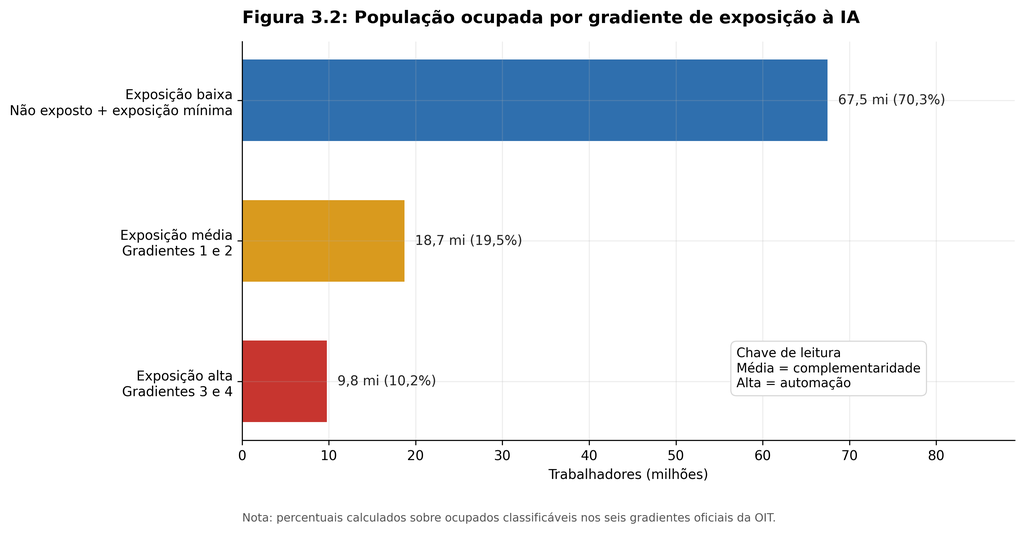

[figure not shown]

A OIT estimou a proporção de trabalhadores com alta exposição à inteligência artificial (Gradientes 3 e 4) para diferentes grupos de países, o que permite uma comparação informativa com os dados encontrados neste estudo. A taxa de trabalhadores altamente expostos no Brasil (10,1%) fica ligeiramente acima da estimativa global da OIT (7,5%) e do padrão projetado para países de renda média-alta (7,0%). No entanto, a distância é expressiva quando comparamos o mercado brasileiro às economias de alta renda, em que a alta exposição atinge 17,3% da força de trabalho. Essa diferença reflete a estrutura ocupacional do país, caracterizada por um peso ainda expressivo de ocupações em setores de baixa exposição tecnológica, como a indústria de transformação tradicional e a agropecuária.

## **3.3 Ocupações mais expostas à IA**

Como o índice de exposição é construído no nível ocupacional, o ponto de partida natural é identificar quais ocupações estão no topo da distribuição. A Figura 3.3 mostra a composição da população ocupada por faixa de score, segundo o grande grupo ocupacional.

**Figura 3.3: Composição da população ocupada por faixa de score de exposição à IA , segundo o grande grupo ocupacional**

[figure not shown]

A figura evidencia uma moda em torno de 0,12 a 0,18, formada por ocupações elementares, da indústria e da agropecuária, e uma cauda secundária por volta de 0,55 a 0,65, composta sobretudo por trabalhadores do apoio administrativo.

A Tabela 3.3 detalha as cinco ocupações em alta exposição com maior contingente de trabalhadores na PNADc. A seleção, portanto, não corresponde aos maiores scores médios absolutos, mas às ocupações dos Gradientes 3 e 4 que concentram mais trabalhadores. No Anexo 1.1 consta a tabela completa, com a média de exposição, o gradiente e o contingente estimado de cada ocupação segundo a COD.

**Tabela 3.3: Top 5 ocupações em alta exposição com maior contingente de trabalhadores**

| **COD** | **Ocupação (descrição ISCO-08)** | **Exposição média** | **Pop. (milhões)** | **Grande grupo** |
| --- | --- | --- | --- | --- |
| 4110 | Auxiliares de escritório em geral | 0,60 | 3,75 | Apoio administrativo |
| 4226 | Caixas, bilheteiros e atendentes em estabelecimentos | 0,57 | 1,04 | Apoio administrativo |
| 2411 | Contabilistas | 0,51 | 0,59 | Profissionais das ciências |
| 4120 | Secretários administrativos e executivos | 0,58 | 0,50 | Apoio administrativo |
| 2431 | Profissionais de marketing, propaganda e relações públicas | 0,55 | 0,43 | Profissionais das ciências |

A leitura confirma um padrão comum às análises baseadas em índices de exposição: as ocupações mais expostas à IA são as chamadas *white collar*. Em termos econômicos, trata-se de funções administrativas e de escritório, centradas em tarefas rotineiras, textuais, contábeis e de atendimento, e em geral associadas a maior escolaridade. O ponto central é que a exposição é ocupacional, não setorial: ela acompanha o tipo de tarefa executada, e não o ramo de atividade da empresa. Por isso, a próxima subseção mostra onde esses trabalhadores estão distribuídos.

## **3.4 Distribuição setorial e regional dos trabalhadores em alta exposição**

Identificadas as ocupações que puxam a exposição, resta mapear onde se encontram os trabalhadores em alta exposição. Convém lembrar, antes, que o trabalho *white collar* existe em praticamente todos os setores da economia: uma indústria tem contabilidade e um hospital tem equipe administrativa. Por isso, não se deve ler a distribuição setorial como se apenas alguns ramos fossem alcançados pela IA; todos os setores têm trabalhadores em ocupações potencialmente expostas, em maior ou menor grau.

A Tabela 3.4 apresenta a distribuição dos trabalhadores em alta exposição por setor, distinguindo duas dimensões: a intensidade da exposição, isto é, a proporção de trabalhadores em alta exposição dentro de cada setor, e o volume, ou seja, o número absoluto de trabalhadores nessa condição. Essa distinção é importante porque setores pequenos podem ter alta intensidade de exposição, enquanto setores grandes podem concentrar maior número de trabalhadores expostos.

**Tabela 3.4: Exposição à IA por setor (CNAE-Domiciliar 2.0, IBGE)**

| Setor | Total (M) | % BR | Exposição Média | Alta (M) | Alta (%) |
| --- | --- | --- | --- | --- | --- |
| Finanças e Seguros | 1.53 | 1.6 | 0.512 | 0.84 | 54.9 |
| Informação e Comunicação | 1.73 | 1.8 | 0.456 | 0.55 | 31.9 |
| Serviços Profissionais | 4.07 | 4.2 | 0.420 | 1.27 | 31.2 |
| Atividades Imobiliárias | 0.70 | 0.7 | 0.386 | 0.12 | 17.8 |
| Administração Pública | 4.27 | 4.5 | 0.352 | 1.12 | 26.3 |
| Comércio | 17.83 | 18.6 | 0.342 | 1.36 | 7.7 |
| Artes e Cultura | 1.10 | 1.1 | 0.316 | 0.10 | 9.4 |
| Saúde | 6.19 | 6.5 | 0.300 | 0.85 | 13.7 |
| Serviços Administrativos | 4.37 | 4.6 | 0.294 | 0.82 | 18.8 |
| Utilidades | 0.72 | 0.8 | 0.293 | 0.11 | 15.2 |
| Educação | 7.18 | 7.5 | 0.290 | 0.65 | 9.0 |
| Transporte | 5.72 | 6.0 | 0.280 | 0.46 | 8.0 |
| Alojamento e Alimentação | 5.09 | 5.3 | 0.266 | 0.23 | 4.4 |
| Ind. Extrativa | 0.59 | 0.6 | 0.262 | 0.04 | 6.4 |
| Ind. Transformação | 11.31 | 11.8 | 0.245 | 0.76 | 6.7 |
| Outros Serviços | 4.04 | 4.2 | 0.219 | 0.25 | 6.3 |
| Serviços Domésticos | 5.30 | 5.5 | 0.160 | 0.00 | 0.0 |
| Agropecuária | 6.97 | 7.3 | 0.155 | 0.06 | 0.8 |
| Construção | 7.23 | 7.5 | 0.146 | 0.18 | 2.5 |

*Nota: universo de ocupados classificáveis (cerca de 96 milhões, excluindo "Sem classificação"). Setores derivados das seções A a T da CNAE-Domiciliar 2.0 (IBGE), a partir da variável V4013. "Exposição Média" é a média ponderada do score contínuo de exposição (0 a 1); "Alta (M)" e "Alta (%)" referem-se aos trabalhadores em Gradientes 3 e 4.*

A Tabela 3.4 evidencia que Finanças e Seguros lidera em intensidade de exposição, com 54,9% de seus trabalhadores em alta exposição (Gradientes 3 e 4). Quando mais da metade de um setor está no nível de maior exposição, isso é representativo de uma transformação em curso. Em termos absolutos, porém, Comércio concentram os maiores contingentes, somando aproximadamente 1.36 milhões de trabalhadores em alta exposição. A relevância, nesse caso, não está tanto na proporção interna de cada setor, mas no número de pessoas em ocupações de alta exposição, o que amplifica o potencial agregado sobre o mercado de trabalho. Assim, a exposição à IA não se restringe aos setores de tecnologia: ela aparece em ocupações administrativas e profissionais distribuídas por diferentes atividades econômicas.

A mesma capilaridade aparece na dimensão regional. Os 9,8 milhões de trabalhadores em alta exposição não são exclusivos de um setor, e tampouco se concentram em um único polo: espalham-se por todos os estados do país. A Figura 3.4 mapeia simultaneamente o volume absoluto e a proporção de trabalhadores em alta exposição em relação à força de trabalho de cada unidade federativa.

**Figura 3.4: Alta exposição à IA por estado**

[figure not shown]

São Paulo concentra o maior contingente em termos absolutos: 2,8 milhões de trabalhadores, o que representa cerca de 12% da força de trabalho paulista. Esse resultado é esperado, pois o estado abriga a maior economia do país, com a maior concentração de sedes corporativas e serviços financeiros. Outros estados, como a Bahia, apresentam proporções consideravelmente menores, reflexo de uma estrutura ocupacional com maior peso de setores agrícolas, industriais e de serviços de baixa exposição.

O caso mais ilustrativo é o Distrito Federal. Apesar de ter uma força de trabalho relativamente pequena em termos absolutos, o DF apresenta a maior proporção de trabalhadores em alta exposição entre todas as UFs, consequência direta do seu perfil ocupacional: capital do país, com altíssima concentração de servidores públicos, analistas, profissionais técnicos e funções administrativas ligadas à máquina pública federal. É o caso em que a proporção diz mais do que o número absoluto.

A leitura combinada dos dois indicadores, volume e proporção, revela um fenômeno relevante para a agenda de políticas públicas. Embora a alta exposição à IA não represente a maioria da força de trabalho em nenhum estado, sua distribuição capilar por todo o território nacional implica que os efeitos potenciais da tecnologia sobre o mercado de trabalho não se restringem a um polo econômico específico. Em estados onde a proporção de trabalhadores altamente expostos é maior, como o DF, o Rio de Janeiro e São Paulo, políticas de requalificação, proteção salarial e monitoramento do emprego formal podem ter impacto proporcionalmente mais significativo sobre a estabilidade do mercado de trabalho local.

## **3.5 Perfil sociodemográfico**

Esta subseção caracteriza o perfil dos trabalhadores brasileiros mais expostos à IA . Como a exposição está concentrada em ocupações administrativas, técnicas e profissionais, ela não se distribui aleatoriamente entre os grupos sociais: decorre da posição dos trabalhadores na estrutura ocupacional. Os resultados mostram maior exposição entre trabalhadores mais escolarizados, mulheres, brancos, jovens e formais, além de concentração relevante nas faixas intermediárias de renda. Os recortes a seguir detalham esse padrão.

### **3.5.1 Análise por sexo**

A Figura 3.5 compara a exposição de mulheres e homens.

**Figura 3.5: Exposição à IA por sexo**

[figure not shown]

A exposição média das mulheres (0,303) é 0,044 ponto maior do que a dos homens (0,259), uma diferença relativa de +17% sobre a média masculina. A leitura mais informativa, porém, não está na média, mas em como a população se distribui entre os níveis de exposição: 14,5% das mulheres ocupadas (6,1 milhões) estão em alta exposição (G3 e G4), contra 6,8% dos homens (3,6 milhões). Proporcionalmente, as mulheres são 2,2 vezes mais presentes na alta exposição do que os homens. O trabalho analítico realizado pela OIT no WP140 aponta no mesmo sentido: em países de alta renda, 41% do emprego feminino está exposto.

### **3.5.2 Análise por raça**

A Figura 3.6 apresenta o recorte racial.

**Figura 3.6: Exposição à IA por raça**

[figure not shown]

O padrão racial é semelhante em magnitude, mas oposto à direção que se costuma esperar em análises de desigualdade: trabalhadores brancos têm exposição média de 0,305, contra 0,257 entre trabalhadores negros, definidos pela agregação de pretos e pardos conforme [Osorio (2003)](https://repositorio.ipea.gov.br/bitstreams/e09cc868-669f-4064-b396-693e22e0ce07/download), uma diferença relativa de +19% sobre a média negra. Em alta exposição, 12,5% dos brancos (5,2 milhões) estão expostos, contra 8,4% dos negros (4,5 milhões): os brancos são 1,5 vez mais presentes na alta exposição, mesmo sendo um contingente 11,9 milhões menor na força de trabalho ocupada (41,5 ante 53,4 milhões). A interpretação econômica conecta-se diretamente ao que foi visto: as ocupações de alta exposição são, em sua maioria, *white collar* e, no Brasil, esse tipo de trabalho está historicamente associado a maior renda e escolaridade. O país carrega um legado de desigualdade racial, com uma estrutura de mercado de trabalho forjada em séculos de escravidão, que concentrou e ainda concentra grande parte da população negra em ocupações elementares, da construção, dos serviços domésticos e da indústria de transformação, setores de alto volume, baixa remuneração e baixa exposição à IA.

### **3.5.3 Análise por faixa etária**

A Figura 3.7 descreve a exposição ao longo da idade.

**Figura 3.7: Exposição à IA por faixa etária**

[figure not shown]

### **3.5.4 Análise por nível de escolaridade**

O gradiente educacional é o mais forte de todos os recortes individuais. A Figura 3.8 mostra esse padrão.

**Figura 3.8: Exposição à IA por nível de escolaridade**

[figure not shown]

A exposição média sobe de 0,179 entre trabalhadores sem instrução ou com fundamental incompleto para 0,275 entre os com médio completo (+54% em relação ao piso), 0,359 entre os com superior incompleto (+102%) e 0,364 entre os com superior completo (+105%), uma variação que mais que dobra a exposição ao longo da distribuição educacional. A interpretação é direta: a escolaridade abre acesso a ocupações de escritório, profissionais e técnicas, e essas são as mais expostas à IA.

### **3.5.5 Análise por renda**

A Figura 3.9 relaciona a exposição e a faixa de renda.

**Figura 3.9: Exposição à IA por faixa de renda**

[figure not shown]

O padrão central é que, embora a exposição média à IA aumente com a renda (de 0,237 na faixa até 1 salário mínimo para 0,365 em 5 ou mais), a **alta exposição** (Gradientes 3 e 4) não cresce indefinidamente: ela sobe de 7,6% na faixa mais baixa para cerca de 12,3% nas faixas intermediárias (1 a 3 salários mínimos) e depois **satura**, ficando praticamente estável mesmo entre os mais ricos. Esse resultado pede cautela na interpretação. Há uma leitura intuitiva, mas equivocada, de que seria a elite intelectual e financeira o grupo mais exposto à IA, afinal é ela que lida com as tarefas mais sofisticadas, digitais e baseadas em conhecimento. Os dados mostram outra direção. A OIT chega à mesma conclusão no WP140: o Gradiente 4, o de maior exposição, concentra-se sobretudo entre os trabalhadores de apoio administrativo, digitadores de dados, escriturários de contabilidade, secretários e caixas. São profissões com tarefas altamente estruturadas, centradas em dados e em linguagem rotineira, exatamente o que os modelos de linguagem fazem com facilidade. Acima desse patamar, a renda passa a refletir mais cargos de gestão e profissões liberais especializadas, que tendem a cair em exposição **moderada** (G1 e G2), não alta. O resultado é que a maior massa de trabalhadores em alta exposição está em salários de até 2 salários mínimos, cerca de dois terços do total, um segmento com menor capacidade de absorver choques. Para o Brasil, isso tem uma implicação direta: os eventuais efeitos distributivos da IA devem aparecer primeiro na classe baixa e média de escritório, e não no topo da pirâmide.

### **3.5.6 Análise por situação de formalidade**

A Figura 3.10 fecha os recortes com a situação de formalidade, que serve de ponte para a etapa empírica.

**Figura 3.10: Exposição à IA por situação de formalidade**

[figure not shown]

A exposição média dos trabalhadores formais (0,305) é 0,046 ponto maior do que a dos informais (0,258), uma diferença relativa de +18% em relação à média informal. Novamente, o contraste é mais nítido na alta exposição: 14,8% dos formais (6,1 milhões) estão em ocupações de alta exposição (G3 e G4), contra apenas 6,7% dos informais (3,6 milhões). Em termos proporcionais, os trabalhadores com vínculo formal são 2,2 vezes mais presentes na alta exposição do que os informais. Apesar de a força de trabalho informal ser 32% maior do que a formal (54,6 ante 41,3 milhões de ocupados), os formais respondem por 63% dos 9,8 milhões em alta exposição (6,1 milhões) e os informais por apenas 37% (3,6 milhões).

A interpretação é estrutural. Os trabalhadores formais, predominantemente empregados CLT em escritórios e na administração pública, concentram-se justamente nas ocupações de alta exposição.

## **3.6 Síntese e implicações para a análise com CAGED**

Esses achados motivam diretamente a próxima etapa. A PNAD oferece um retrato transversal: mede a exposição e caracteriza o perfil dos trabalhadores, mas não acompanha a dinâmica do emprego ao longo do tempo. Para investigar se a exposição à IA se traduz em mudanças efetivas no mercado de trabalho, é preciso uma base longitudinal do emprego formal. Isso é o que vamos fazer na próxima seção.

# 4 Estratégia Empírica

## 4.1 Abordagem de diferenças em diferenças

Para a estratégia empírica, a principal referência foi a abordagem de diferenças em diferenças e de estudo de eventos aplicados à difusão da IA feita por [Brynjolfsson, Chandar e Chen (2025)](https://digitaleconomy.stanford.edu/publication/canaries-in-the-coal-mine-six-facts-about-the-recent-employment-effects-of-artificial-intelligence/). Esse estudo acompanhou o mercado de trabalho americano a partir dos registros de folha de pagamento da ADP, uma das maiores processadoras de folha dos Estados Unidos, que paga salários para mais de 25 milhões de trabalhadores. Como a empresa processa esses pagamentos mês a mês, os autores conseguem observar admissões, desligamentos e salários em altíssima frequência e quase em tempo real, montando um painel mensal de milhões de vínculos por firma. Essa granularidade permitiu detectar ajustes finos por ocupação e por idade logo após o lançamento do ChatGPT. O principal achado do estudo é que esse ajuste se concentrou na porta de entrada do mercado: os trabalhadores mais jovens, de 22 a 25 anos, em ocupações mais expostas, como desenvolvimento de software e atendimento ao cliente, apresentaram queda relativa de cerca de 16% no emprego, na especificação com controles de firma e tempo da versão de 13 de novembro de 2025, enquanto o emprego dos trabalhadores mais velhos e experientes nas mesmas ocupações permaneceu estável ou até cresceu.

No Brasil, o equivalente mais próximo dessa base é o CAGED (Cadastro Geral de Empregados e Desempregados), estatística administrativa do Ministério do Trabalho e Emprego construída a partir de informações do eSocial, do CAGED e do Empregador Web. Desde janeiro de 2020, a maior parte das empresas cumpre a obrigação de informar admissões e desligamentos pelo eSocial, e os registros são consolidados mensalmente. Essa obrigatoriedade dá ao CAGED cobertura praticamente completa do mercado formal em frequência mensal, o que o torna adequado para acompanhar a porta de entrada e de saída do emprego, justamente a margem em que a literatura internacional tem encontrado os primeiros sinais de ajuste à IA. A adaptação ao Brasil, porém, exige duas ressalvas em relação ao artigo de referência. Primeiro, o CAGED observa fluxos formais de admissões e desligamentos, e não o estoque mensal de trabalhadores por firma. Segundo, a variação de exposição vem do índice da OIT aplicado à CBO, e não de quintis construídos sobre a classificação ocupacional americana. Por isso, o que se faz aqui é uma análise da dinâmica do emprego formal brasileiro em ocupações mais expostas, e não uma reprodução direta do painel firma-trabalhador do artigo de referência.

O desenho não capta a adoção direta de IA dentro das firmas, pois o CAGED não informa se uma empresa usa ChatGPT ou ferramentas semelhantes. O que se estima é se ocupações mais expostas passaram a apresentar evolução diferencial após a difusão da tecnologia. O choque temporal vem da difusão pública da IA, e a intensidade do tratamento vem da exposição ocupacional medida pela OIT. O evento escolhido é o lançamento público do ChatGPT, em 30 de novembro de 2022, tratado como marco inicial da difusão dos LLMs (*Large Language Models*). Essa escolha dialoga com a literatura recente e é o evento usado no estudo de referência de [Brynjolfsson, Chandar e Chen (2025)](https://digitaleconomy.stanford.edu/publication/canaries-in-the-coal-mine-six-facts-about-the-recent-employment-effects-of-artificial-intelligence/).

## **4.2 Construção do painel ocupação-mês com CAGED e crosswalk CBO → OIT**

Como vimos anteriormente, enquanto a PNAD utiliza a COD (Classificação de Ocupações para Pesquisas Domiciliares), a taxonomia usada no CAGED é a CBO (Classificação Brasileira de Ocupações). Por isso, a unidade de análise desta etapa é a ocupação CBO de quatro dígitos observada mês a mês. A partir dos microdados do CAGED, construo, para cada ocupação e período, medidas agregadas de admissões, desligamentos, saldo líquido e salários médios de admissão e desligamento.

**Tabela 4.2.1 — Escopo do painel ocupação-mês**

| Indicador | Valor |
| --- | --- |
| Observações CBO-mês | 23.319 |
| CBOs únicos | 436 |
| Meses | 54 |
| Janela | 2021-01 a 2025-06 |

A janela de análise começa em janeiro de 2021 por duas razões. Primeiro, o Novo CAGED teve início em janeiro de 2020, não havendo dados diretamente comparáveis para períodos anteriores. Segundo, optei por excluir o ano de 2020 porque ele coincide com a fase mais aguda da pandemia de Covid-19, marcada por fortes alterações nas admissões, nos desligamentos e nos salários. A inclusão desse período poderia fazer com que os efeitos excepcionais da pandemia fossem confundidos com as tendências anteriores à difusão do ChatGPT. Assim, o painel compreende o período entre janeiro de 2021 e junho de 2025, preservando aproximadamente 23 meses anteriores ao evento e 31 meses posteriores.

O principal desafio metodológico é fazer a correspondência do CBO, usada nos registros administrativos brasileiros, com o índice da OIT, construído em ISCO-08. Para evitar uma correspondência ad hoc entre códigos numericamente parecidos, adotei uma ponte institucional em duas etapas. Primeiro, usei a tábua oficial do Ministério do Trabalho e Emprego que relaciona CBO 2002, CBO 94 e CIUO/ISCO-88. Em seguida, converti os códigos ISCO-88 para ISCO-08 por meio da tabela de correspondência da OIT. O caminho completo é, portanto: CBO 2002 → CBO94/CIUO88 via MTE → ISCO-08 via OIT → índice de exposição da OIT. A correspondência é mantida apenas quando existe uma ponte institucional identificável entre a família ocupacional brasileira e a classificação internacional.

As 193 CBOs sem correspondência válida são classificadas como *No score* e ficam fora da amostra principal, pois a ausência de score indica falta de correspondência oficial, não ausência de exposição. Como a relação entre CBO e ISCO é muitas-para-muitas, uma mesma CBO de quatro dígitos pode estar associada a mais de um destino ISCO-08. Nesses casos, reuni os destinos ISCO-08 com score disponível e calculei uma medida agregada de exposição para a CBO. A classificação final preserva a lógica do índice da OIT, combinando o nível médio de exposição e a dispersão das tarefas associadas à ocupação. Com isso, a atribuição de exposição não depende de um único destino ocupacional, mas de uma média dos códigos internacionais associados àquela família CBO. Como mostra a Tabela 4.2.2, a classificação final organiza as CBOs em seis grupos.

**Tabela 4.2.2 — Classificação das CBOs segundo o índice da OIT e definição de grupos de tratamento e controle.**

| Categoria OIT | CBOs | Match MTE | Tratamento | Controle | Excluído | Média score | SD pooled |
| --- | --- | --- | --- | --- | --- | --- | --- |
| Exposed: Gradient 4 | 0 | 0 |  |  |  |  |  |
| Exposed: Gradient 3 | 31 | 31 | ✓ |  |  | 0,539 | 0,114 |
| Exposed: Gradient 2 | 31 | 31 | ✓ |  |  | 0,452 | 0,121 |
| Exposed: Gradient 1 | 13 | 13 | ✓ |  |  | 0,356 | 0,167 |
| Minimal Exposure | 95 | 95 |  |  | ✓ | 0,329 | 0,123 |
| Not Exposed | 266 | 266 |  | ✓ |  | 0,202 | 0,080 |
| No score | 193 | 0 |  |  | ✓ |  |  |

Um ponto importante dessa classificação é que nenhuma CBO de quatro dígitos ficou no Gradiente 4, o de maior exposição, como mostra a Tabela 4.2.2. Isso é uma consequência direta do crosswalk: como uma mesma CBO costuma corresponder a vários códigos ISCO-08, a exposição atribuída à ocupação vem da agregação desses destinos. Essa média tende a diluir os picos de exposição, pois scores individualmente altos são atenuados ao serem combinados com destinos menos expostos. O resultado é que a classificação no nível da CBO dificilmente alcança o gradiente mais extremo e, na amostra observada do CAGED, o grupo mais forte fica vazio.

Essa diluição é atenuada pela forma como o grupo de tratamento foi definido. Reuni os Gradientes 1, 2, 3 e 4 em um único grupo de ocupações expostas. Assim, uma ocupação cujo score foi diluído continua classificada como exposta, ainda que em um gradiente mais baixo do que teria sob uma correspondência perfeita. A contrapartida é que o crosswalk perde precisão dentro de cada gradiente: ele não sustenta, com segurança, análises que tratem os gradientes de forma isolada, comparando, por exemplo, o Gradiente 3 diretamente com o Gradiente 1. Por isso, a exposição é usada principalmente de forma binária, entre expostos e não expostos, e as análises por gradiente específico ficam em segundo plano.

Definido o grupo tratado, resta delimitar o controle. O modelo principal compara esse grupo tratado com as ocupações Not Exposed, que formam o controle estrito. O grupo Minimal Exposure fica fora do controle principal porque representa uma categoria intermediária: são ocupações com exposição média baixa, mas com alguma dispersão de tarefas potencialmente expostas. Incluí-las no controle poderia enfraquecer o contraste entre ocupações efetivamente não expostas e ocupações expostas. Por isso, Minimal Exposure entra apenas como especificação de robustez com controle ampliado.

**Tabela 4.2.3: Cobertura do painel por grupo de exposição**

| Categoria | CBOs | % do total | Observações CBO-mês | % das observações |
| --- | --- | --- | --- | --- |
| Exposed | 75 | 11,9% | 4.050 | 17,4% |
| Not Exposed | 266 | 42,3% | 14.257 | 61,1% |
| Minimal Exposure | 95 | 15,1% | 5.012 | 21,5% |
| No score | 193 | 30,7% | 0 | 0,0% |

## **4.3 Especificação econométrica e outcomes**

Definidos o evento, o tratamento e o painel, resta especificar o modelo que estima o efeito da exposição à IA sobre o emprego formal e detalhar quais outcomes esse modelo procura explicar.

Cada termo do modelo cumpre um papel específico:

- $Yc,t$ é o outcome da ocupação $c$, a CBO de quatro dígitos, no mês $t$.
- $Tratadoc×Poˊst$ é a interação que identifica o efeito: assume valor 1 para ocupações expostas no período posterior ao ChatGPT e 0 nos demais casos.
- $β$ é o coeficiente de interesse, que mede a mudança diferencial das ocupações expostas em relação às não expostas depois do choque.
- $αc$ são os efeitos fixos de ocupação, que absorvem diferenças estruturais e constantes entre CBOs, como nível médio de salário e intensidade de contratação.
- $δt$ são os efeitos fixos de mês, que absorvem choques comuns a todas as ocupações em um dado mês, como sazonalidade, inflação agregada e ciclo econômico.
- $Xc,t$ reúne os controles de composição dos admitidos.
- $εc,t$ é o termo de erro, com erros-padrão clusterizados no nível da CBO de quatro dígitos.

Podemos interpretar: como $αc$ remove o que cada ocupação tem de fixo e $δt$ remove o que é comum a cada mês, $β$ capta apenas o que muda de forma diferente nas ocupações expostas justamente após o ChatGPT.

Além do modelo estático, estimo estudos de eventos que substituem a interação única $Tratado×Poˊs$ por interações entre o tratamento e cada mês relativo ao evento, tomando o mês imediatamente anterior ao choque como referência. Esse desenho tem duas funções: mostrar como o efeito evolui ao longo do tempo e testar se as ocupações tratadas já seguiam trajetória diferente antes do ChatGPT.

Uma decisão adicional diz respeito aos controles de composição em $Xc,t$, como idade média, participação feminina, participação com ensino superior e composição racial dos admitidos. Eles reduzem diferenças observáveis entre ocupações, mas podem ser afetados pelo próprio tratamento, caso a IA altere quem é contratado. Por isso, reporto também especificações sem controles e com controles pré-tratamento interagidos com o pós, e trato essa comparação como parte da validação do desenho.

O mesmo modelo é aplicado a diferentes outcomes, porque a difusão da IA pode atingir o mercado formal por várias margens: reduzir contratações, mudar a composição dos desligamentos, afetar salários de entrada ou alterar o saldo líquido de vínculos. A Tabela 4.3.1 resume os outcomes principais, sua definição e a transformação usada na estimação.

**Tabela 4.3.1: Outcomes da análise**

| **Grupo** | **Outcome** | **Definição** | **Transformação** |
| --- | --- | --- | --- |
| Fluxos | Admissões | Número de admissões formais na ocupação-mês | $log(y+1)$; Poisson na robustez |
| Fluxos | Desligamentos | Número de desligamentos formais na ocupação-mês | $log(y+1)$; Poisson na robustez |
| Salários | Salário real de admissão | Salário médio de admissão deflacionado pelo IPCA | $log$ |
| Saldo | Saldo líquido | Admissões menos desligamentos na ocupação-mês | $asinh(saldo)$ |

A escolha das transformações segue a natureza de cada outcome. Os fluxos de admissões e desligamentos são contagens com muitos zeros, o que motiva o $log(y+1)$ no modelo principal e os modelos de Poisson na robustez. Os salários são deflacionados pelo IPCA para isolar variação real. O saldo líquido usa $asinh(saldo)$ porque a medida pode ser negativa ou zero, e essa transformação preserva o sinal e permite estimar em toda a amostra.

## **4.4 Heterogeneidade e mecanismos**

A literatura internacional sugere que os efeitos da IA generativa podem aparecer primeiro em trabalhadores no início da carreira. [Brynjolfsson, Chandar e Chen (2025)](https://digitaleconomy.stanford.edu/publication/canaries-in-the-coal-mine-six-facts-about-the-recent-employment-effects-of-artificial-intelligence/) mostram que, nos Estados Unidos, a queda relativa de emprego em ocupações expostas é mais intensa entre trabalhadores de 22 a 25 anos. A interpretação é que trabalhadores jovens dependem mais de conhecimento codificado, adquirido na educação formal, enquanto trabalhadores mais experientes acumulam conhecimento tácito e específico da firma. Se a IA substitui parte desse conhecimento codificado, os jovens podem ser mais vulneráveis. Agrupei idade conforme aplicado na PNAD, para ajudar na interpretação e comparação dos resultados da seção 3, mas também adotei as faixas etárias inspiradas no artigo de referência: 22-25, 26-30, 31-34, 35-40, 41-49 e 50 anos ou mais. Para dialogar com essa hipótese, essas faixas ajudam a separar o início da carreira de estágios mais avançados da trajetória profissional.

Na Seção 3, vimos que alguns perfis sociodemográficos, como mulheres e pessoas com alta escolaridade, estão mais expostos. Por esse motivo, estimo heterogeneidades por idade, sexo, raça/cor, escolaridade e renda. Nos exercícios que cruzam perfis sociodemográficos e grupos ocupacionais, a heterogeneidade é estimada por grupo e por um modelo de diferenças-em-diferenças triplas (DDD). O coeficiente de interesse interage o período posterior ao lançamento do ChatGPT, o indicador de pertencimento ao grupo ocupacional tratado e o indicador do perfil analisado. Assim, ele mede se a mudança pós-ChatGPT no grupo tratado, relativamente às ocupações não expostas, difere entre o perfil em questão e seu complemento.

Também construí seis casos ocupacionais para investigar mecanismos: desenvolvedores de software, atendimento ao cliente, gerentes de marketing e vendas, supervisores de produção, estoquistas e repositores e auxiliares de saúde e cuidado. Os casos foram definidos semanticamente a partir das descrições oficiais das CBOs de seis dígitos, congelados antes da inspeção dos resultados e reúnem 76 códigos sem sobreposição. A composição segundo a OIT é usada posteriormente para interpretar os casos, não para selecioná-los por palavras-chave.

# 5 Resultados

## 5.1 Resultados médios nacionais

A Tabela 5.1 apresenta as estimativas médias nacionais do modelo de diferenças em diferenças, comparando ocupações expostas à IA (gradientes da OIT) às não expostas após o lançamento do ChatGPT. Os coeficientes medem a variação relativa das ocupações expostas.

**Tabela 5.1: Resultados médios nacionais**

| Amostra | Admissões (log) | Desligamentos (log) | Salário real de admissão (log) |
| --- | --- | --- | --- |
| Nacional | -0,0309 (0,0263) | -0,0417 (0,0254) | -0,0207 (0,0140) |

> *Notas: as células apresentam o coeficiente DiD e, entre parênteses, o erro-padrão clusterizado por CBO de quatro dígitos. \* p<0,10; * *p<0,05; \*** p<0,01. O tratamento compara as CBOs expostas segundo os gradientes da OIT às CBOs classificadas como `Not Exposed`.*

Os resultados são predominantemente nulos: os três coeficientes têm sinal negativo, mas nenhum é estatisticamente significativo. As reduções aproximadas são de 3,0% nas admissões, 4,1% nos desligamentos e 2,0% no salário real de admissão. As estimativas pontuais são numericamente não desprezíveis, mas imprecisas; como não foi definido um limiar ex ante de relevância econômica, elas não devem ser classificadas como economicamente relevantes.

Para admissões e desligamentos, a interpretação causal é ainda mais limitada: os testes de tendências paralelas são rejeitados, indicando que os grupos já divergiam antes do ChatGPT. Como admissões e desligamentos caem simultaneamente, o padrão é compatível com menor movimentação dos fluxos. Entretanto, como o modelo não observa o estoque de emprego, ele não permite concluir se houve ou não destruição líquida de vínculos.

A Figura 5.1 apresenta os coeficientes mensais dos event studies (painéis superiores, com intervalos de confiança de 95%) e as trajetórias normalizadas pela média pré-tratamento (painéis inferiores, descritivos).

**Figura 5.1: Resultados nacionais: event studies e trajetórias**

[file ref: figure_s5_2_national_main_outcomes_event_study_paths.png]

[figure not shown]

O padrão mais consistente está no salário real de admissão: o teste de tendências paralelas não é rejeitado e, no pós-tratamento, os coeficientes são negativos, com os salários de entrada das ocupações expostas abaixo dos das não expostas. Ainda assim, os intervalos de confiança frequentemente incluem zero e a estimativa média não é significativa, de modo que o resultado é sugestivo, não conclusivo.

Esse quadro é coerente com a fronteira recente da literatura empírica sobre IA e emprego. [Brynjolfsson, Chandar e Chen (2025)](https://digitaleconomy.stanford.edu/publication/canaries-in-the-coal-mine-six-facts-about-the-recent-employment-effects-of-artificial-intelligence/), principal referência desta seção, também não encontram diferenças significativas no emprego agregado entre ocupações mais e menos expostas e enfrentam o mesmo problema de tendências paralelas: ocupações altamente expostas foram atingidas de forma distinta pela pandemia de Covid-19, o que contamina a linha de base anterior ao ChatGPT. A literatura recente encontra efeitos agregados pequenos ou nulos em alguns desenhos de curto prazo, mas também resultados negativos em subgrupos, firmas e ocupações; portanto, o padrão ainda não deve ser chamado de consolidado. [Humlum e Vestergaard (2025)](https://www.nber.org/papers/w33777), com dados administrativos da Dinamarca, reportam efeitos nulos e precisos sobre ganhos e horas mesmo dois anos após o ChatGPT; análises com a Current Population Survey dos Estados Unidos ([Chandar, 2025](https://papers.ssrn.com/sol3/papers.cfm?abstract_id=5384519)) não identificam diferenças sistemáticas entre ocupações expostas e não expostas; e Aldasoro *et al.* (2026), com mais de 12 mil firmas não financeiras da União Europeia e dos Estados Unidos, associam a adoção de IA a um aumento de 4% na produtividade do trabalho, sem efeito adverso sobre o emprego no nível da firma no curto prazo. A leitura de que os sinais negativos simultâneos em admissões e desligamentos refletem menor rotatividade, e não destruição de vínculos, também encontra respaldo direto: [Hosseini Maasoum e Lichtinger (2025)](https://papers.ssrn.com/sol3/papers.cfm?abstract_id=5425555) mostram que a contração do emprego em firmas que adotam IA vem sobretudo da desaceleração das contratações, acompanhada de queda nos desligamentos, e [Klein Teeselink (2025)](https://papers.ssrn.com/sol3/papers.cfm?abstract_id=5516798), no Reino Unido, documenta reduções tanto no emprego quanto nas novas vagas; o artigo descreve a queda das vagas como gradual e com cronologia semelhante à do estoque, não como anterior a qualquer ajuste no emprego.

Em resumo, não há efeito médio nacional robusto: admissões e desligamentos são imprecisos e violam as tendências paralelas, e a evidência mais coerente, no salário de admissão, aponta no máximo para uma redução modesta nos salários de entrada das ocupações expostas. Esse resultado nulo acompanha o que a literatura internacional tem encontrado: no período e nas amostras examinadas, vários estudos encontram efeitos agregados pequenos ou nulos, com heterogeneidade e incerteza; isso não permite concluir que a IA não produza efeitos futuros ou concentrados em subgrupos. A própria literatura sugere por que a média nacional se aproxima de zero, pois o efeito é fortemente assimétrico entre grupos. É essa assimetria, com efeitos concentrados na porta de entrada do mercado, que motiva deslocar a análise do agregado nacional para os grupos sociodemográficos, objeto da próxima subseção.

## **5.2 Heterogeneidades demográficas**

### **5.2.1 Efeitos por Sexo**

A Tabela 5.2.1 apresenta os efeitos por sexo. O painel principal reporta as estimativas dentro de cada grupo, enquanto o Painel B, no apêndice, testa formalmente as diferenças entre homens e mulheres por meio do modelo DDD.

**Tabela 5.2.1: Resultados por sexo**

| Grupo | Admissões (log) | Desligamentos (log) | Salário real de admissão (log) | Saldo líquido (asinh) |
| --- | --- | --- | --- | --- |
| Homens | -0,0387 (0,0265) | -0,0561** (0,0268) | -0,0156 (0,0163) | -0,3300 (0,3404) |
| Mulheres | -0,0817*** (0,0279) | -0,0626** (0,0283) | -0,0367*** (0,0125) | -1,0562*** (0,3077) |

> *Notas: as células apresentam o coeficiente DiD e, entre parênteses, o erro-padrão clusterizado por CBO de quatro dígitos. \* p<0,10; ** p<0,05; *** p<0,01. A diferença formal entre os grupos é testada pelo modelo DDD apresentado no apêndice. O saldo em transformação asinh não deve ser interpretado como percentual.*

A principal diferença aparece nas admissões. Nas ocupações expostas, as admissões femininas diminuem aproximadamente 7,8%, ante 3,8% entre os homens. O DDD indica uma queda adicional de 4,4% para as mulheres (p=0,018), com tendências prévias compatíveis e suporte amostral adequado.

Os desligamentos também diminuem nos dois grupos, mas sem diferença significativa entre eles (p=0,773). Portanto, a assimetria de gênero concentra-se na entrada no emprego, e não nos desligamentos. No salário de admissão, a redução é maior entre as mulheres, mas o DDD não é significativo (p=0,205) e apresenta violação da tendência linear prévia. O saldo líquido aponta na mesma direção, porém seus diagnósticos são menos estáveis e o resultado deve ser tratado como complementar.

As Figuras 5.2.1.1 e 5.2.1.2 apresentam os event studies e as trajetórias de admissões e salário de admissão por sexo.

**Figura 5.2.1.1: Admissões — event study e trajetórias por sexo**

[file ref: figure_s5_2_sex_admissions_event_study_paths.png]

[figure not shown]

**Figura 5.2.1.2: Salário real de admissão — event study e trajetórias por sexo**

[file ref: figure_s5_2_sex_real_admission_wage_event_study_paths.png]

[figure not shown]

Nas admissões, não há evidência de divergências sistemáticas antes do ChatGPT. Após o lançamento, os coeficientes femininos são predominantemente negativos e as trajetórias das mulheres expostas permanecem abaixo das não expostas durante grande parte do período. Embora os intervalos mensais incluam zero, o padrão é compatível com o efeito médio estimado pelo DDD.

No salário, as trajetórias sugerem um padrão mais negativo para as mulheres, mas os intervalos de confiança incluem zero e o DDD médio não é significativo. Portanto, não há evidência robusta de diferença salarial entre homens e mulheres.

O resultado das admissões contrasta parcialmente com [Brynjolfsson, Chandar e Chen (2025)](https://digitaleconomy.stanford.edu/publication/canaries-in-the-coal-mine-six-facts-about-the-recent-employment-effects-of-artificial-intelligence/), que encontram efeitos semelhantes para homens e mulheres nos Estados Unidos. Por outro lado, sua direção converge com a análise da Subseção 3.5.1 e com Gmyrek *et al.* (2025), que apontam maior exposição ocupacional das mulheres à IA. Em conjunto, o resultado é compatível com uma redução relativa pós-ChatGPT das admissões femininas nas ocupações expostas, mas o desenho não observa adoção de IA e não permite afirmar que a exposição potencial esteja se materializando como efeito realizado.

Em resumo, a heterogeneidade por sexo concentra-se nas admissões: o diferencial pós-ChatGPT foi mais negativo para as admissões femininas nas ocupações expostas, sem diferença correspondente nos desligamentos. As evidências para salários e saldo permanecem exploratórias. Se persistente, esse padrão pode limitar o papel dessas ocupações como canais de inserção e mobilidade profissional para as mulheres, desacelerando a convergência entre os sexos no acesso às oportunidades de trabalho. Embora esta análise não permita afirmar que essa consequência já esteja ocorrendo, o resultado reforça a importância de acompanhar as admissões femininas e investigar se essas trabalhadoras estão sendo direcionadas para outras ocupações ou enfrentando uma redução efetiva de oportunidades.

### 5.2.2 **Efeitos** por raça/cor

A Tabela 5.2.2 apresenta os efeitos por raça/cor, comparando trabalhadores brancos e negros, categoria que agrega pretos e pardos. O Painel A reporta os efeitos DiD dentro de cada grupo. Os contrastes DDD, os diagnósticos de tendências paralelas e as medidas de saldo estão apresentados no Painel B, no Apêndice A.

**Tabela 5.2.2: Heterogeneidade por raça/cor — Branca e Negra**

| Grupo | Admissões (log) | Desligamentos (log) | Salário real de admissão (log) | Saldo líquido (asinh) |
| --- | --- | --- | --- | --- |
| Branca | -0,0486* (0,0280) | -0,0254 (0,0247) | -0,0096 (0,0142) | -0,3389 (0,3078) |
| Negra (preta e parda) | -0,0167 (0,0250) | -0,0510* (0,0283) | -0,0234 (0,0142) | -0,2858 (0,2685) |

> *Notas: as células apresentam o coeficiente DiD e, entre parênteses, o erro-padrão clusterizado por CBO de quatro dígitos. \* p<0,10; ** p<0,05; *** p<0,01. A diferença formal entre os grupos é testada pelo modelo DDD apresentado no apêndice. O saldo em transformação asinh não deve ser interpretado como percentual.*

Os coeficientes do Painel A são negativos para os dois grupos. As admissões de trabalhadores brancos caem aproximadamente 4,7%, enquanto os desligamentos de trabalhadores negros recuam cerca de 5,0%, ambos com significância apenas a 10%. A diferença entre essas estimativas, entretanto, deve ser avaliada pelo DDD.

O Painel B confirma essa leitura. Não há diferença significativa entre brancos e negros nas admissões (−0,0236) nem no salário real de admissão (−0,0108). A única heterogeneidade estatisticamente clara aparece nos desligamentos, cuja redução é cerca de 3,2% maior entre trabalhadores negros (−0,0322), com tendências paralelas favoráveis. Como esse recuo dos desligamentos não é acompanhado por queda equivalente nas admissões, o resultado é compatível com menor movimentação dos fluxos, mas, sem observar o estoque de emprego, não permite distinguir menor rotatividade de mudanças no número líquido de vínculos.

As Figuras 5.2.2.1 e 5.2.2.2 apresentam os estudos de eventos e as trajetórias normalizadas para admissões e salário real de admissão.

**Figura 5.2.2.1 Admissões — event study e trajetórias por raça/cor**

[file ref: figure_s5_2_race_color_b_admissions_event_study_paths.png]

[figure not shown]

**Figura 5.2.2.2: Salário real de admissão — event study e trajetórias por raça/cor**

[file ref: figure_s5_2_race_color_b_real_admission_wage_event_study_paths.png]

[figure not shown]

Nos dois outcomes, os pretrends são aprovados, mas os coeficientes mensais oscilam em torno de zero e seus intervalos de confiança frequentemente incluem zero. As figuras, portanto, reforçam a ausência de diferenças raciais robustas nas admissões e nos salários de entrada.

Esse resultado complementa a Subseção 3.5.2. Embora os trabalhadores brancos estejam mais presentes em ocupações altamente expostas, não há evidência robusta de que o diferencial pós-ChatGPT entre ocupações expostas e não expostas tenha variado. A comparação internacional permanece limitada, pois os principais estudos empíricos mobilizados nesta dissertação não apresentam estimativas causais desagregadas por raça ([Brynjolfsson; Chandar; Chen, 2025](https://digitaleconomy.stanford.edu/publication/canaries-in-the-coal-mine-six-facts-about-the-recent-employment-effects-of-artificial-intelligence/); [Hosseini Maasoum; Lichtinger, 2025](https://papers.ssrn.com/sol3/papers.cfm?abstract_id=5425555); [Klein Teeselink, 2025](https://papers.ssrn.com/sol3/papers.cfm?abstract_id=5516798)).

Em resumo, não há evidência de que a exposição à IA tenha ampliado as diferenças raciais nas admissões ou nos salários de entrada. A única diferença aparece na maior redução dos desligamentos de trabalhadores negros, sem efeito correspondente sobre o saldo líquido.

### 5.2.3 **Efeitos** por faixa etária

**Tabela 5.2.3: Heterogeneidade por faixa etária — faixas PNAD/IBGE**

| Faixa etária | Admissões (log) | Desligamentos (log) | Salário real de admissão (log) | Saldo líquido (asinh) |
| --- | --- | --- | --- | --- |
| 18–24 | -0,0339 (0,0272) | -0,0303 (0,0319) | -0,0386** (0,0156) | -0,0699 (0,2034) |
| 25–34 | -0,0390 (0,0276) | -0,0722*** (0,0271) | -0,0183 (0,0137) | -0,6196* (0,3558) |
| 35–44 | -0,0314 (0,0266) | -0,0268 (0,0263) | -0,0350** (0,0151) | -0,5936* (0,3079) |
| 45–54 | -0,0106 (0,0272) | 0,0033 (0,0269) | -0,0147 (0,0151) | -0,2923 (0,2232) |
| 55–65 | -0,0085 (0,0280) | -0,0035 (0,0234) | -0,0213 (0,0170) | 0,3359** (0,1369) |

> *Notas: as células apresentam o coeficiente DiD e, entre parênteses, o erro-padrão clusterizado por CBO de quatro dígitos. \* p<0,10; ** p<0,05; *** p<0,01. A amostra é restrita a trabalhadores de 18 a 65 anos.*

As admissões não seguem um gradiente monotônico por idade (seção 3.7): os coeficientes são negativos em todas as faixas, mas nenhum é significativo dentro do grupo, e no DDD apenas a faixa de 25 a 34 anos registra queda relativa, de cerca de 2,0%. Pela classificação de Brynjolfsson, Chandar e Chen, a retração se concentra no fim dos vinte anos: entre 22 e 25 anos ocorre apenas dentro do grupo, enquanto entre 26 e 30 anos chega a 5,6% no DiD e 2,7% no DDD.

O resultado mais consistente está nos desligamentos de 25 a 34 anos, com queda de cerca de 7,0% no DiD e adicional de 5,5% no DDD, confirmada entre 26 e 30 e entre 31 e 34 anos pela classificação alternativa. Como os desligamentos caem mais do que as admissões, o padrão é compatível com menor movimentação relativa dos fluxos; sem observar o estoque, não é possível distinguir esse padrão de mudanças no número líquido de vínculos.

Nos salários de admissão, as quedas de 3,8% entre 18 e 24 anos e de 3,4% entre 35 e 44 anos são significativas apenas dentro dos grupos: o efeito dos mais jovens não difere das demais idades e o de 35 a 44 anos é apenas limítrofe (p=0,050). As medidas de saldo permanecem instáveis e entram como evidência complementar.

As Figuras 5.2.3.1 e 5.2.3.2 apresentam os event studies e as trajetórias de admissões e salário real de admissão para todas as faixas da PNAD/IBGE. Os painéis superiores mostram os coeficientes mensais do DDD e os respectivos intervalos de confiança, enquanto os painéis inferiores apresentam as trajetórias descritivas das ocupações expostas e não expostas dentro de cada faixa.

**Figura 5.2.3.1: Heterogeneidade por idade — Admissões**

[file ref: figure_s5_2_age_pnad_all_age_groups_admissions_event_study_paths.png]

[figure not shown]

**Figura 5.2.3.2: Heterogeneidade por idade — Salário real de admissão**

[file ref: figure_s5_2_age_pnad_all_age_groups_real_admission_wage_event_study_paths.png]

[figure not shown]

Nas admissões, a faixa de 25 a 34 anos apresenta alerta no pretrend conjunto (p=0,061), enquanto 55–65 anos rejeita o pretrend (p=0,024). No salário real de admissão, 18–24 anos rejeita o teste conjunto (p=0,014) e 45–54 anos é classificada como falha por três coeficientes pré-tratamento significativos, embora o teste conjunto tenha p=0,159. A figura, portanto, evidencia comportamentos distintos entre as faixas, mas não estabelece uma hierarquia etária causal clara.

Os resultados brasileiros não reproduzem a concentração inequívoca do efeito entre 22 e 25 anos encontrada por [Brynjolfsson, Chandar e Chen (2025)](https://digitaleconomy.stanford.edu/publication/canaries-in-the-coal-mine-six-facts-about-the-recent-employment-effects-of-artificial-intelligence/). Essa diferença pode decorrer dos desenhos dos estudos: os autores analisam o estoque de emprego e comparam quintis de exposição, com efeitos concentrados nos níveis mais elevados, enquanto esta dissertação examina fluxos de admissões e desligamentos e utiliza uma classificação mais ampla de ocupações expostas.

Além disso, enquanto Hosseini Maasoum e Lichtinger encontram redução do emprego júnior principalmente pela desaceleração das contratações, o resultado mais preciso desta análise está na queda dos desligamentos.

Em resumo, a maior exposição dos jovens documentada na Seção 3.5.3 não se converte em uma retração diferenciada das admissões entre 18 e 24 anos. A heterogeneidade mais consistente concentra-se entre 25 e 34 anos e aponta para menor rotatividade nas ocupações expostas.

Entre os mais jovens, aparece uma possível redução do salário de entrada, mas sem diferença significativa em relação às demais idades e com limitações no event study. Os resultados não confirmam um deslocamento concentrado nos trabalhadores mais jovens, mas sugerem ajustes distintos: menor movimentação dos vínculos entre 25 e 34 anos e possível pressão sobre a remuneração de entrada entre 18 e 24 anos.

### 5.2.4 Efeitos por nível de escolaridade

**Tabela 5.2.4: Heterogeneidade por nível de escolaridade**

| Grupo | Admissões (log) | Desligamentos (log) | Salário real de admissão (log) | Saldo líquido (asinh) |
| --- | --- | --- | --- | --- |
| Fundamental ou menos | -0,0160 (0,0320) | -0,0264 (0,0310) | 0,0127 (0,0216) | 0,2618 (0,1789) |
| Médio | -0,0244 (0,0252) | -0,0124 (0,0292) | -0,0230 (0,0170) | -0,4628 (0,3226) |
| Superior | -0,0725*** (0,0254) | -0,0568** (0,0257) | -0,0226* (0,0121) | -1,1578*** (0,3132) |

Os efeitos negativos concentram-se nos trabalhadores com ensino superior. Nesse grupo, as admissões diminuem aproximadamente 7,0% e os desligamentos, 5,5%, enquanto os resultados para os níveis médio e fundamental não são significativos.

O contraste mais consistente aparece nos desligamentos: o DDD indica queda adicional de 7,0% para o ensino superior (p=0,001), com tendências prévias compatíveis. Nas admissões, a redução relativa é maior, próxima de 9,9% (p<0,001), mas o pretrend do DDD apresenta alerta e o event study rejeita as tendências paralelas. O resultado sugere retração da entrada, mas é menos robusto.

Não há heterogeneidade salarial clara. Os coeficientes dos grupos médio e superior são semelhantes, próximos de -2,3%, e o DDD do ensino superior não é significativo. As medidas de saldo também não são estáveis. Assim, a queda conjunta das admissões e dos desligamentos indica menor dinamismo dos vínculos, sem permitir concluir que houve redução líquida do emprego.

As Figuras 5.2.4.1 e 5.2.4.2 apresentam os event studies e as trajetórias de admissões e salário real de admissão por escolaridade.

**Figura 5.2.4.1: Admissões — event study e trajetórias por escolaridade**

[file ref: figure_s5_2_education_admissions_event_study_paths.png]

[figure not shown]

**Figura 5.2.4.2: Salário real de admissão — event study e trajetórias por escolaridade**

[file ref: figure_s5_2_education_real_admission_wage_event_study_paths.png]

[figure not shown]

Nas admissões, as trajetórias do ensino superior mantêm as ocupações expostas abaixo das não expostas. Entretanto, o event study não apresenta uma trajetória DDD negativa estável e rejeita o pretrend, limitando sua interpretação causal. Nos salários, os coeficientes mensais oscilam ao redor de zero e os intervalos de confiança frequentemente incluem zero, reforçando a ausência de heterogeneidade salarial robusta.

O resultado converge com a Subseção 3.5.4, que mostrou aumento expressivo da exposição à IA com a escolaridade. Também é compatível com [Klein Teeselink (2025)](https://papers.ssrn.com/sol3/papers.cfm?abstract_id=5516798), que encontra efeitos concentrados em firmas e ocupações de alta remuneração no Reino Unido. A comparação não é direta, pois remuneração não equivale a escolaridade. [Brynjolfsson, Chandar e Chen (2025)](https://digitaleconomy.stanford.edu/publication/canaries-in-the-coal-mine-six-facts-about-the-recent-employment-effects-of-artificial-intelligence/) mostram ainda que ocupações com menor proporção de graduados também podem ser afetadas, enquanto [Hosseini Maasoum e Lichtinger (2025)](https://papers.ssrn.com/sol3/papers.cfm?abstract_id=5425555) identificam diferenças importantes dentro do próprio ensino superior.

Em resumo, a heterogeneidade educacional concentra-se nos fluxos de trabalhadores com ensino superior, sobretudo nos desligamentos. As admissões também apresentam forte retração, mas com limitações nos pretrends. Não há diferença salarial robusta nem evidência segura de contração líquida do emprego.

### **5.2.5 Efeitos por faixa salarial ocupacional**

**Tabela 5.2.5: Efeitos dentro dos grupos por faixa salarial ocupacional**

| Faixa de renda | Admissões (log) | Desligamentos (log) | Salário real de admissão (log) | Saldo líquido (asinh) |
| --- | --- | --- | --- | --- |
| Até 2 salários mínimos | 0,0167 (0,0304) | -0,0196 (0,0328) | -0,0174 (0,0184) | 0,0962 (0,3781) |
| Mais de 2 até 5 salários mínimos | -0,1381** (0,0537) | -0,1895*** (0,0466) | -0,0250 (0,0231) | -1,0279 (0,8018) |
| Mais de 5 salários mínimos | -0,0229 (0,1463) | 0,1957 (0,1360) | -0,0046 (0,0376) | -3,9568 (2,1677) |

> Notas: as células apresentam o coeficiente DiD e, entre parênteses, o erro-padrão clusterizado por CBO de quatro dígitos. * p<0,10; ** p<0,05; *** p<0,01. As faixas utilizam a mediana salarial pré-tratamento da CBO, expressa em salários mínimos, e não a renda individual corrente.

Os efeitos concentram-se na faixa de 2 a 5 salários mínimos, com reduções estimadas de aproximadamente 13% nas admissões e 17% nos desligamentos. A evidência mais consistente está nos desligamentos, cujo contraste DDD é significativo e apresenta tendências prévias compatíveis. Ainda assim, o resultado se baseia em 28 CBOs expostas e 32 não expostas, número suficiente para a estimação, mas relativamente limitado. Para as admissões, a falha nos pretrends exige interpretação exploratória.

Na faixa de até 2 salários mínimos, os efeitos dentro do grupo não são significativos. Contudo, os contrastes DDD são positivos: +15,0% nas admissões (β=0,1399; p=0,015), com falha de pretrend, e +12,6% nos desligamentos (β=0,1182; p=0,035), com pretrends compatíveis. Esses sinais contrapõem o padrão negativo da faixa intermediária e precisam constar da síntese. Acima de 5 salários mínimos, a limitação é mais severa: existem apenas 3 CBOs expostas e 7 não expostas. Embora essas ocupações reúnam observações mensais e possivelmente muitos trabalhadores, a comparação depende de apenas 10 ocupações distintas. Por isso, as estimativas são voláteis e não permitem concluir que o segmento de maior remuneração esteja protegido. O DDD dos desligamentos é positivo e nominalmente significativo (+27,8%; β=0,2453; p=0,049), mas depende de apenas 3 CBOs tratadas e 7 controles; por isso, deve ser reportado e explicitamente descartado como base para inferência substantiva.

A Figura 5.2.5.1 apresenta os event studies e as trajetórias das admissões por renda pré-tratamento.

**Figura 5.2.5.1: Admissões — event studies e trajetórias por renda pré-tratamento**

[file ref: figure_s5_2_income_admissions_event_study_paths.png]

[figure not shown]

A maior volatilidade da faixa superior decorre do pequeno número de ocupações: os coeficientes dependem de apenas 3 CBOs expostas e 7 não expostas, o que amplia a incerteza das estimativas.

A Figura 5.2.5.2 apresenta os resultados para o salário real de admissão.

**Figura 5.2.5.2: Salário real de admissão — event studies e trajetórias por renda pré-tratamento**

[file ref: figure_s5_2_income_real_admission_wage_event_study_paths.png]

[figure not shown]

Os coeficientes salariais oscilam em torno de zero e seus intervalos de confiança são amplos. Os testes conjuntos não rejeitam os pretrends nas duas primeiras faixas (p=0,417 e p=0,277), mas ambas são classificadas como falha porque apresentam três coeficientes pré-tratamento individualmente significativos. No topo, o teste conjunto é limítrofe (p=0,057) e gera alerta. Não há, portanto, evidência de heterogeneidade salarial robusta.

O resultado dialoga com a Subseção 3.5.5, que mostrou que a alta exposição cresce até as faixas intermediárias e depois se estabiliza. A comparação é apenas indicativa, pois aquela análise classifica trabalhadores por renda, enquanto esta utiliza a mediana salarial da CBO. O padrão também converge parcialmente com [Klein Teeselink (2025)](https://papers.ssrn.com/sol3/papers.cfm?abstract_id=5516798), que encontra maior ajuste nos segmentos de alta remuneração do Reino Unido e pouca alteração nos de baixa remuneração. A correspondência não é exata: nesta dissertação, o sinal concentra-se na faixa intermediária e o topo possui suporte insuficiente. Já a ausência de efeitos salariais é compatível com [Brynjolfsson, Chandar e Chen (2025)](https://digitaleconomy.stanford.edu/publication/canaries-in-the-coal-mine-six-facts-about-the-recent-employment-effects-of-artificial-intelligence/), que encontram ajustes mais visíveis no emprego do que na remuneração.

Em resumo, os resultados sugerem menor movimentação nas ocupações expostas situadas entre 2 e 5 salários mínimos, sobretudo pela redução dos desligamentos. A evidência sobre admissões é limitada pelos pretrends; não há heterogeneidade salarial robusta; as estimativas de saldo incluem sinais nominais, mas são comprometidas por falhas de pretrend ou suporte muito fino e não sustentam uma conclusão substantiva. Não há base suficiente para concluir que a IA protege o topo, produz compressão salarial ou reduz o emprego líquido.

### **5.2.6 Síntese das heterogeneidades demográficas**

A análise por grupos demográficos revela um padrão comum aos cinco recortes: os diferenciais pós-ChatGPT entre ocupações expostas e não expostas no emprego formal são modestos, concentram-se nos fluxos e aparecem de forma seletiva, sem configurar um choque generalizado. A retração das admissões é mais nítida entre as mulheres, com queda adicional de 4,4% no DDD, e entre os trabalhadores com ensino superior, enquanto a redução dos desligamentos é o resultado mais robusto e recorrente, presente entre trabalhadores negros, na faixa de 25 a 34 anos, no ensino superior e nas ocupações de renda intermediária, entre 2 e 5 salários mínimos. Como admissões e desligamentos caem ao mesmo tempo na maioria dos grupos, o quadro é compatível com menor movimentação relativa dos fluxos; sem observar o estoque, não é possível distinguir esse padrão de mudanças no número líquido de vínculos. Os salários de admissão e o saldo líquido não apresentam heterogeneidade robusta: os coeficientes são instáveis, com frequência limitados por falhas nos testes de tendências prévias, e devem ser lidos como evidência complementar. A síntese deve registrar também os DDDs positivos da faixa de até 2 salários mínimos (+15,0% nas admissões e +12,6% nos desligamentos) e o contraste positivo, porém sem suporte, nos desligamentos acima de 5 salários mínimos. Como não há correção por testes múltiplos, todos os achados de heterogeneidade permanecem exploratórios.

Em conjunto, esses resultados qualificam o efeito médio nulo da Seção 5.1: a ausência de evidência agregada robusta convive com ajustes localizados justamente nos grupos mais expostos. Ainda assim, os resultados são compatíveis com ajustes localizados nos fluxos de ocupações mais expostas após o ChatGPT, mas não permitem concluir que a IA já esteja redistribuindo oportunidades ou preservando o volume total de emprego. A exposição não mede adoção, o estoque não é observado e várias especificações falham nos pretrends; por isso, a expressão 'acomodação silenciosa' deve ser apresentada apenas como hipótese de discussão. Os achados também dialogam com o retrato descritivo da Seção 3, pois os mesmos perfis identificados como mais expostos, as mulheres, os trabalhadores mais escolarizados e os das faixas intermediárias de renda, são os que concentram os primeiros sinais de ajuste. Ainda assim, a leitura deve permanecer cautelosa: a recorrência de falhas nos pretrends, o suporte amostral limitado em algumas faixas e a natureza exploratória do desenho impedem uma interpretação causal firme. Como hipótese de discussão, o padrão sugere uma acomodação silenciosa do emprego formal, marcada por menor movimentação de entrada e saída nas ocupações expostas, e não por uma onda de demissões, o que reforça a importância de acompanhar essas margens à medida que a tecnologia se difunde.

## 5.3 Casos ocupacionais e trajetórias por idade

Para aproximar a discussão brasileira dos seis exemplos de *Canaries in the Coal Mine*, esta subseção acompanha as trajetórias de seis casos ocupacionais definidos semanticamente a partir das descrições oficiais da CBO de seis dígitos. A seleção foi congelada antes da inspeção dos resultados e reúne 76 códigos sem sobreposição. Para cada caso, calculo mensalmente as admissões e o salário real médio dos admitidos nas faixas de 22–25, 26–30, 31–34, 35–40, 41–49 e 50 anos ou mais, normalizando outubro de 2022 em 1. A medida resumida no texto é a média de janeiro a junho de 2025 em relação a essa base. Como não há um grupo de controle próprio para cada caso, as figuras são descritivas: seus diagnósticos anteriores ao choque medem cobertura, inclinação e volatilidade, mas não constituem testes causais de tendências paralelas. Nos salários, valores positivos foram winsorizados nos percentis 1 e 99 dentro de cada CBO de seis dígitos e ano, pois os registros brutos continham valores manifestamente implausíveis; as médias sem esse ajuste permanecem como sensibilidade no Apêndice B.

A Tabela 5.3.1 mostra que a correspondência semântica não produz uma ordenação brasileira idêntica à do artigo. Desenvolvedores concentram 64,6% das admissões prévias no Gradiente 3 e 29,9% no Gradiente 2 da OIT, enquanto atendimento está integralmente no Gradiente 3 e marketing e vendas, no Gradiente 2. Em contraste, supervisores de produção são majoritariamente não expostos (58,3%) ou não possuem escore (36,2%); estoquistas e repositores estão integralmente em exposição mínima; e auxiliares de saúde e cuidado combinam ocupações não expostas (62,4%) e minimamente expostas (37,6%). Essa composição é usada para interpretar os casos depois de selecionados, não para criar novos rótulos de exposição; em particular, ausência de escore não significa exposição zero.

**Tabela 5.3.1: Seleção e composição da exposição dos casos ocupacionais**

| Caso ocupacional | CBOs (n) | Confiança semântica | Referência em *Canaries* | Composição OIT no Brasil | Admissões pré-tratamento |
| --- | --- | --- | --- | --- | --- |
| Desenvolvedores de software | 7 | Alta | Alta exposição | G3 64,6%; G2 29,9%; sem escore 5,5% | 293.893 |
| Atendimento ao cliente | 2 | Alta | Alta exposição | G3 100,0% | 160.341 |
| Gerentes de marketing e vendas | 2 | Alta | Quintil 4 | G2 100,0% | 68.132 |
| Supervisores de produção | 53 | Moderada | Quintil 3 | não exposto 58,3%; exposição mínima 5,5%; sem escore 36,2% | 62.953 |
| Estoquistas e repositores | 5 | Alta | Quintil 2 | exposição mínima 100,0% | 1.593.069 |
| Auxiliares de saúde e cuidado | 7 | Moderada | Quintil 1 | não exposto 62,4%; exposição mínima 37,6% | 147.801 |

> *Nota: a composição da OIT é ponderada pelas admissões entre janeiro de 2021 e outubro de 2022. A seleção dos casos usa títulos e tarefas oficiais da CBO de seis dígitos e é independente dessa classificação.*

**Figura 5.3.1: Trajetórias mensais de admissões por caso ocupacional e idade**

[ref file: figure_5_3_1_occupation_cases_admissions_by_age.png]

[figure not shown]

Nas admissões, o contraste mais claro aparece entre os casos mais expostos na classificação brasileira e os casos de exposição mínima, não exposta ou sem escore. Entre desenvolvedores, a média de janeiro a junho de 2025 fica abaixo de outubro de 2022 em todas as faixas etárias, com quedas de 6,9% entre 22–25 anos, 4,9% entre 26–30 e 11,6% entre 31–34. Atendimento ao cliente também recua nas três faixas mais jovens, entre 9,7% e 15,0%, mas cresce 17,3% entre 41–49 anos e 29,7% entre trabalhadores com 50 anos ou mais. Em marketing e vendas, as três faixas abaixo de 35 anos permanecem próximas ou abaixo da base, enquanto as duas mais velhas crescem 16,0% e 40,0%. Já estoquistas e auxiliares de saúde apresentam expansão em todas as idades, particularmente entre os mais velhos. Dos 36 contrastes caso×idade, 33 preservam o sinal quando a base passa para a média de janeiro a outubro de 2022 e quando cada mês de 2025 é comparado ao mesmo mês de 2022. Supervisores também crescem na maior parte das faixas, mas devem ser lidos com cautela porque seus 53 códigos apresentam maior mudança de composição interna ao longo do período.

**Figura 5.3.2: Trajetórias mensais do salário real de admissão por caso ocupacional e idade**

[ref file: figure_5_3_2_occupation_cases_real_admission_wage_by_age.png]

[figure not shown]

O salário real de admissão acrescenta uma margem distinta, porém menos uniforme. Em atendimento ao cliente, a variação é positiva nas seis idades, de 3,5% a 9,3%, e em estoquistas varia de 3,1% a 5,7%; ambos os padrões mantêm o sinal nas duas bases alternativas. Marketing e vendas apresenta variações predominantemente negativas, enquanto auxiliares de saúde e cuidado registram quedas grandes acima de 30 anos, entre 29,3% e 48,8%; neste último caso, a forte volatilidade anterior e a combinação de ocupações clínicas e de cuidado exigem cautela adicional. Por outro lado, os salários de supervisores ficam próximos de zero e mudam de sinal conforme a normalização, e as reduções modestas em software também são sensíveis à base para a maior parte das idades. Por isso, a figura reporta todos os resultados, inclusive os instáveis, mas a interpretação substantiva se restringe aos 25 de 36 contrastes salariais que preservam a direção nas duas sensibilidades temporais.

O recorte etário, portanto, reforça uma assimetria na porta de entrada: software e atendimento exibem contratações mais fracas entre jovens, ao passo que estoque e saúde crescem em todas as idades e com maior intensidade entre trabalhadores mais velhos. As explorações adicionais por sexo, raça/cor e escolaridade foram submetidas a uma regra prévia de consistência entre os seis casos, suporte e normalizações. Somente a comparação racial em admissões satisfez todos os critérios: a variação entre pessoas negras foi maior que entre pessoas brancas nos seis casos, com diferença mediana de 31,3 pontos percentuais. Esse resultado é apenas descritivo e pode refletir mudanças mais amplas de composição ou de demanda; sexo, escolaridade e os contrastes salariais não revelaram padrão transversal suficientemente estável e permanecem no Apêndice B.

Em conjunto, os casos brasileiros dialogam com [Brynjolfsson, Chandar e Chen (2025)](https://digitaleconomy.stanford.edu/publication/canaries-in-the-coal-mine-six-facts-about-the-recent-employment-effects-of-artificial-intelligence/) ao localizar o ajuste mais visível nas contratações de trabalhadores mais jovens em ocupações ligadas a software e atendimento. A comparação, entretanto, não é equivalente: o artigo acompanha estoque de emprego em firmas, enquanto o CAGED registra fluxo de admissões formais, e a classificação de exposição da OIT também difere dos quintis utilizados pelos autores. Assim, esta subseção não altera a conclusão causal das Seções 5.1 e 5.2. Seu papel é mostrar que a média nacional encobre trajetórias ocupacionais e etárias bastante distintas, compatíveis com uma reconfiguração seletiva das oportunidades de entrada, mas também com sazonalidade, composição ocupacional e outros choques não isolados por este exercício.

## Apêndice A: Contrastes DDD e diagnósticos das heterogeneidades

Este apêndice reúne os contrastes entre cada grupo e seu complemento, estimados por diferenças em diferenças triplas (DDD), além dos diagnósticos de tendências prévias, suporte amostral e tamanho das amostras. Os diagnósticos de pretrend das heterogeneidades testam uma tendência linear no período anterior ao tratamento e, portanto, não correspondem ao teste conjunto do estudo de eventos nacional. Os p-valores são convencionais e não recebem correção por testes múltiplos. As análises devem ser consideradas exploratórias, sobretudo quando o pretrend falha ou o suporte é classificado como insuficiente.

### A.1 Diagnósticos do modelo nacional

**Tabela A.1: Diagnósticos dos resultados médios nacionais**

Painel B.1: Estimativas DiD e diagnósticos dos outcomes principais

| Resultado | DiD nacional | p DiD | Pretrend | N | CBOs |
| --- | --- | --- | --- | --- | --- |
| Admissões (log) | -0,0309<br>(0,0263) | 0,241 | fail (p=0,001) | 18.307 | 341 |
| Desligamentos (log) | -0,0417<br>(0,0254) | 0,102 | fail (p=0,031) | 18.307 | 341 |
| Salário real de admissão (log) | -0,0207<br>(0,0140) | 0,140 | pass (p=0,932) | 18.307 | 341 |
| Saldo líquido (asinh) | -0,6597*<br>(0,3773) | 0,081 | fail (p<0,001) | 18.307 | 341 |

Painel B.2: Robustez da construção do saldo

| Resultado | DiD nacional | p DiD | Pretrend | N | CBOs |
| --- | --- | --- | --- | --- | --- |
| Saldo líquido / admissões pré | 0,0119<br>(0,0193) | 0,537 | fail (p<0,001) | 18.299 | 340 |
| Saldo líquido / fluxo total | 0,0042<br>(0,0088) | 0,629 | not_available | 18.307 | 341 |

Notas: as células do Painel A apresentam o coeficiente DiD nacional e, entre parênteses, o erro-padrão. O Painel B.1 repete essas estimativas para reunir p-valores, pretrends e suporte da amostra; não se trata de um contraste DDD, pois não há divisão por subgrupo. Os erros-padrão são clusterizados por CBO de quatro dígitos. * p<0,10; ** p<0,05; *** p<0,01. O tratamento compara CBOs expostas nos gradientes da OIT a CBOs `Not Exposed`; `Minimal Exposure` não integra o controle principal. O pretrend do Painel B é o teste conjunto dos coeficientes mensais anteriores ao tratamento; `not_available` indica que o teste conjunto não foi estimado para aquela construção. `asinh(saldo)` aceita valores negativos e zero e não deve ser interpretado como percentual. `Saldo/admissões pré` normaliza pelo porte pré-tratamento da CBO; `saldo/fluxo total` divide o saldo por admissões mais desligamentos no mês. As duas medidas do Painel B.2 são checagens de robustez, não outcomes principais. Os p-valores são convencionais e não recebem correção por testes múltiplos. N denota observações CBO-mês, não trabalhadores. A Tabela A.1 usa o teste da especificação original na amostra completa (N=18.307), enquanto a Figura 5.1 usa a janela estrita t=−12,…,24, sem agrupamento de caudas (N=12.538). Os p-valores diferem, embora a classificação pass/fail seja a mesma.

### A.2 Sexo

**Tabela A.2: Contrastes DDD e diagnósticos por sexo**

Painel B.1: Contrastes DDD e diagnósticos dos outcomes principais

| Grupo | Resultado | DDD grupo–complemento | p DDD | Pretrend grupo | Pretrend DDD | Poder grupo | N grupo | CBOs trat./controle |
| --- | --- | --- | --- | --- | --- | --- | --- | --- |
| Homens | Admissões (log) | 0,0446**<br>(0,0189) | 0,018 | pass (p=0,402) | pass (p=0,826) | adequate | 18.307 | 75/266 |
| Homens | Desligamentos (log) | 0,0058<br>(0,0201) | 0,773 | warning (p=0,059) | pass (p=0,580) | adequate | 18.307 | 75/266 |
| Homens | Salário real de admissão (log) | 0,0209<br>(0,0165) | 0,205 | pass (p=0,165) | fail (p=0,004) | adequate | 18.227 | 75/266 |
| Homens | Saldo líquido (asinh) | 0,7374***<br>(0,2091) | <0,001 | warning (p=0,062) | fail (p=0,018) | adequate | 18.286 | 75/266 |
| Mulheres | Admissões (log) | -0,0446**<br>(0,0189) | 0,018 | pass (p=0,883) | pass (p=0,826) | adequate | 18.307 | 75/266 |
| Mulheres | Desligamentos (log) | -0,0058<br>(0,0201) | 0,773 | pass (p=0,216) | pass (p=0,580) | adequate | 18.307 | 75/266 |
| Mulheres | Salário real de admissão (log) | -0,0209<br>(0,0165) | 0,205 | fail (p=0,011) | fail (p=0,004) | adequate | 17.695 | 75/265 |
| Mulheres | Saldo líquido (asinh) | -0,7374***<br>(0,2091) | <0,001 | pass (p=0,724) | fail (p=0,018) | adequate | 17.990 | 75/266 |

Painel B.2: Robustez da construção do saldo

| Grupo | Resultado | DDD grupo–complemento | p DDD | Pretrend grupo | Pretrend DDD | Poder grupo | N grupo | CBOs trat./controle |
| --- | --- | --- | --- | --- | --- | --- | --- | --- |
| Homens | Saldo líquido / admissões pré | 0,0679***<br>(0,0189) | <0,001 | warning (p=0,057) | pass (p=0,952) | adequate | 18.278 | 75/265 |
| Homens | Saldo líquido / fluxo total | 0,0171**<br>(0,0079) | 0,030 | fail (p=0,011) | pass (p=0,769) | adequate | 18.286 | 75/266 |
| Mulheres | Saldo líquido / admissões pré | -0,0679***<br>(0,0189) | <0,001 | pass (p=0,576) | pass (p=0,952) | adequate | 17.981 | 75/264 |
| Mulheres | Saldo líquido / fluxo total | -0,0171**<br>(0,0079) | 0,030 | pass (p=0,131) | pass (p=0,769) | adequate | 17.990 | 75/266 |

Notas: as células apresentam o coeficiente e, entre parênteses, o erro-padrão. Os erros-padrão são clusterizados por CBO de quatro dígitos. * p<0,10; ** p<0,05; *** p<0,01. O Painel A estima o DiD na amostra do próprio grupo. O Painel B usa o DDD `pós × tratamento × grupo` e um teste de Wald qui-quadrado para verificar formalmente se esse efeito difere do complemento. Os diagnósticos de pretrend das heterogeneidades testam uma tendência linear no período pré-tratamento; não são o teste conjunto do event study nacional. `asinh(saldo)` aceita valores negativos e zero e não deve ser interpretado como percentual. `Saldo/admissões pré` e `saldo/fluxo total` aparecem no Painel B.2 apenas como checagens de robustez. `N grupo` denota observações CBO-mês, não trabalhadores. O poder é um diagnóstico de suporte por CBOs tratadas/controle: `adequate` requer pelo menos 20/50, `limited` requer 10/25 e `thin` indica suporte inferior. Os p-valores são convencionais, sem correção por testes múltiplos; por isso, as heterogeneidades são exploratórias. Resultados com pretrend falho ou poder `thin` exigem cautela. Em dimensões binárias, os DDDs dos dois grupos são espelhados por construção e não constituem testes independentes.

### A.3 Raça/cor

Painel B.1: Contrastes DDD e diagnósticos dos outcomes principais

| Grupo | Resultado | DDD grupo–complemento | p DDD | Pretrend grupo | Pretrend DDD | Poder grupo | N grupo | CBOs trat./controle |
| --- | --- | --- | --- | --- | --- | --- | --- | --- |
| Branca | Admissões (log) | 0,0236<br>(0,0163) | 0,147 | warning (p=0,076) | pass (p=0,131) | adequate | 18.307 | 75/266 |
| Branca | Desligamentos (log) | 0,0322***<br>(0,0124) | 0,009 | pass (p=0,894) | pass (p=0,230) | adequate | 18.307 | 75/266 |
| Branca | Salário real de admissão (log) | 0,0108<br>(0,0158) | 0,492 | pass (p=0,619) | pass (p=0,504) | adequate | 18.159 | 75/266 |
| Branca | Saldo líquido (asinh) | 0,1817<br>(0,1787) | 0,309 | pass (p=0,184) | pass (p=0,505) | adequate | 18.259 | 75/266 |
| Negra (preta e parda) | Admissões (log) | -0,0236<br>(0,0163) | 0,147 | pass (p=0,337) | pass (p=0,131) | adequate | 18.307 | 75/266 |
| Negra (preta e parda) | Desligamentos (log) | -0,0322***<br>(0,0124) | 0,009 | pass (p=0,299) | pass (p=0,230) | adequate | 18.307 | 75/266 |
| Negra (preta e parda) | Salário real de admissão (log) | -0,0108<br>(0,0158) | 0,492 | pass (p=0,560) | pass (p=0,504) | adequate | 18.181 | 75/266 |
| Negra (preta e parda) | Saldo líquido (asinh) | -0,1817<br>(0,1787) | 0,309 | pass (p=0,267) | pass (p=0,505) | adequate | 18.263 | 75/266 |

### A.4 Idade

Painel B.1: Contrastes DDD e diagnósticos dos outcomes principais (PNAD/IBGE)

| Grupo | Resultado | DDD grupo–complemento | p DDD | Pretrend grupo | Pretrend DDD | Poder grupo | N grupo | CBOs trat./controle |
| --- | --- | --- | --- | --- | --- | --- | --- | --- |
| 18–24 | Admissões (log) | 0,0060<br>(0,0157) | 0,704 | pass (p=0,505) | pass (p=0,256) | adequate | 18.307 | 75/266 |
| 18–24 | Desligamentos (log) | 0,0209<br>(0,0215) | 0,331 | pass (p=0,115) | pass (p=0,433) | adequate | 18.307 | 75/266 |
| 18–24 | Salário real de admissão (log) | -0,0199<br>(0,0191) | 0,298 | pass (p=0,902) | pass (p=0,928) | adequate | 17.947 | 75/266 |
| 18–24 | Saldo líquido (asinh) | 0,7359*<br>(0,3989) | 0,065 | fail (p=0,008) | pass (p=0,298) | adequate | 18.119 | 75/266 |
| 25–34 | Admissões (log) | -0,0197*<br>(0,0117) | 0,092 | pass (p=0,442) | pass (p=0,355) | adequate | 18.307 | 75/266 |
| 25–34 | Desligamentos (log) | -0,0569***<br>(0,0116) | <0,001 | pass (p=0,540) | pass (p=0,546) | adequate | 18.307 | 75/266 |
| 25–34 | Salário real de admissão (log) | -0,0016<br>(0,0132) | 0,907 | pass (p=0,744) | pass (p=0,805) | adequate | 18.181 | 75/266 |
| 25–34 | Saldo líquido (asinh) | -0,0325<br>(0,2201) | 0,883 | pass (p=0,811) | pass (p=0,385) | adequate | 18.272 | 75/266 |
| 35–44 | Admissões (log) | 0,0087<br>(0,0123) | 0,480 | pass (p=0,182) | pass (p=0,262) | adequate | 18.307 | 75/266 |
| 35–44 | Desligamentos (log) | 0,0229*<br>(0,0119) | 0,054 | pass (p=0,816) | pass (p=0,167) | adequate | 18.307 | 75/266 |
| 35–44 | Salário real de admissão (log) | -0,0244*<br>(0,0125) | 0,050 | pass (p=0,303) | pass (p=0,119) | adequate | 18.111 | 75/266 |
| 35–44 | Saldo líquido (asinh) | -0,0924<br>(0,2570) | 0,719 | pass (p=0,305) | fail (p=0,022) | adequate | 18.242 | 75/266 |
| 45–54 | Admissões (log) | 0,0343**<br>(0,0167) | 0,040 | warning (p=0,066) | fail (p=0,048) | adequate | 18.307 | 75/266 |
| 45–54 | Desligamentos (log) | 0,0501***<br>(0,0168) | 0,003 | pass (p=0,637) | fail (p=0,047) | adequate | 18.307 | 75/266 |
| 45–54 | Salário real de admissão (log) | 0,0073<br>(0,0153) | 0,634 | pass (p=0,148) | pass (p=0,108) | adequate | 17.782 | 75/266 |
| 45–54 | Saldo líquido (asinh) | 0,4210<br>(0,3109) | 0,176 | pass (p=0,685) | pass (p=0,468) | adequate | 18.103 | 75/266 |
| 55+ | Admissões (log) | 0,0379<br>(0,0248) | 0,126 | warning (p=0,071) | pass (p=0,115) | adequate | 18.307 | 75/266 |
| 55+ | Desligamentos (log) | 0,0413*<br>(0,0225) | 0,066 | fail (p<0,001) | fail (p<0,001) | adequate | 18.307 | 75/266 |
| 55+ | Salário real de admissão (log) | -0,0012<br>(0,0187) | 0,949 | pass (p=0,364) | pass (p=0,282) | adequate | 16.635 | 75/265 |
| 55+ | Saldo líquido (asinh) | 1,0860***<br>(0,3524) | 0,002 | fail (p<0,001) | warning (p=0,093) | adequate | 17.685 | 75/266 |

Painel B.2: Robustez da construção do saldo (PNAD/IBGE)

| Grupo | Resultado | DDD grupo–complemento | p DDD | Pretrend grupo | Pretrend DDD | Poder grupo | N grupo | CBOs trat./controle |
| --- | --- | --- | --- | --- | --- | --- | --- | --- |
| 18–24 | Saldo líquido / admissões pré | -0,0200<br>(0,0175) | 0,254 | fail (p=0,028) | pass (p=0,865) | adequate | 18.111 | 75/265 |
| 18–24 | Saldo líquido / fluxo total | -0,0112<br>(0,0100) | 0,264 | warning (p=0,064) | pass (p=0,796) | adequate | 18.119 | 75/266 |
| 25–34 | Saldo líquido / admissões pré | 0,0382**<br>(0,0172) | 0,026 | pass (p=0,319) | pass (p=0,263) | adequate | 18.264 | 75/265 |
| 25–34 | Saldo líquido / fluxo total | 0,0239***<br>(0,0086) | 0,006 | pass (p=0,481) | pass (p=0,215) | adequate | 18.272 | 75/266 |
| 35–44 | Saldo líquido / admissões pré | -0,0133<br>(0,0157) | 0,396 | pass (p=0,641) | pass (p=0,701) | adequate | 18.234 | 75/265 |
| 35–44 | Saldo líquido / fluxo total | -0,0096<br>(0,0083) | 0,247 | warning (p=0,053) | pass (p=0,593) | adequate | 18.242 | 75/266 |
| 45–54 | Saldo líquido / admissões pré | -0,0308<br>(0,0244) | 0,206 | pass (p=0,849) | pass (p=0,934) | adequate | 18.095 | 75/265 |
| 45–54 | Saldo líquido / fluxo total | -0,0106<br>(0,0115) | 0,357 | pass (p=0,828) | pass (p=0,677) | adequate | 18.103 | 75/266 |
| 55+ | Saldo líquido / admissões pré | -0,0325<br>(0,0856) | 0,705 | warning (p=0,066) | warning (p=0,054) | adequate | 17.676 | 75/264 |
| 55+ | Saldo líquido / fluxo total | -0,0084<br>(0,0180) | 0,642 | fail (p<0,001) | fail (p<0,001) | adequate | 17.685 | 75/266 |

Notas: as células apresentam o coeficiente e, entre parênteses, o erro-padrão. Os erros-padrão são clusterizados por CBO de quatro dígitos. * p<0,10; ** p<0,05; *** p<0,01. O Painel A estima o DiD na amostra do próprio grupo. O Painel B usa o DDD `pós × tratamento × grupo` e um teste de Wald qui-quadrado para verificar formalmente se esse efeito difere do complemento. Os diagnósticos de pretrend das heterogeneidades testam uma tendência linear no período pré-tratamento; não são o teste conjunto do event study nacional. `asinh(saldo)` aceita valores negativos e zero e não deve ser interpretado como percentual. `Saldo/admissões pré` e `saldo/fluxo total` aparecem no Painel B.2 apenas como checagens de robustez. `N grupo` denota observações CBO-mês, não trabalhadores. O poder é um diagnóstico de suporte por CBOs tratadas/controle: `adequate` requer pelo menos 20/50, `limited` requer 10/25 e `thin` indica suporte inferior. Os p-valores são convencionais, sem correção por testes múltiplos; por isso, as heterogeneidades são exploratórias. Resultados com pretrend falho ou poder `thin` exigem cautela. A amostra desta alternativa é restrita a trabalhadores de 18 a 65 anos; portanto, a faixa exibida como 55+ corresponde a 55–65 anos.

Painel B.1: Contrastes DDD e diagnósticos dos outcomes principais (coortes Canaries)

| Grupo | Resultado | DDD grupo–complemento | p DDD | Pretrend grupo | Pretrend DDD | Poder grupo | N grupo | CBOs trat./controle |
| --- | --- | --- | --- | --- | --- | --- | --- | --- |
| 22–25 | Admissões (log) | -0,0138<br>(0,0134) | 0,304 | pass (p=0,724) | warning (p=0,088) | adequate | 18.307 | 75/265 |
| 22–25 | Desligamentos (log) | -0,0014<br>(0,0185) | 0,938 | pass (p=0,173) | pass (p=0,733) | adequate | 18.307 | 75/265 |
| 22–25 | Salário real de admissão (log) | -0,0211<br>(0,0159) | 0,184 | pass (p=0,540) | pass (p=0,549) | adequate | 17.863 | 75/265 |
| 22–25 | Saldo líquido (asinh) | 0,5343<br>(0,4055) | 0,188 | warning (p=0,053) | pass (p=0,249) | adequate | 18.112 | 75/265 |
| 26–30 | Admissões (log) | -0,0272**<br>(0,0117) | 0,020 | pass (p=0,642) | pass (p=0,153) | adequate | 18.307 | 75/266 |
| 26–30 | Desligamentos (log) | -0,0342***<br>(0,0105) | 0,001 | pass (p=0,363) | pass (p=0,934) | adequate | 18.307 | 75/266 |
| 26–30 | Salário real de admissão (log) | -0,0050<br>(0,0128) | 0,696 | pass (p=0,291) | pass (p=0,234) | adequate | 18.036 | 75/266 |
| 26–30 | Saldo líquido (asinh) | 0,2740<br>(0,1844) | 0,137 | pass (p=0,581) | pass (p=0,568) | adequate | 18.210 | 75/266 |
| 31–34 | Admissões (log) | 0,0129<br>(0,0134) | 0,336 | pass (p=0,148) | pass (p=0,309) | adequate | 18.307 | 75/266 |
| 31–34 | Desligamentos (log) | -0,0240**<br>(0,0114) | 0,036 | pass (p=0,761) | pass (p=0,110) | adequate | 18.307 | 75/266 |
| 31–34 | Salário real de admissão (log) | 0,0053<br>(0,0147) | 0,719 | pass (p=0,534) | pass (p=0,325) | adequate | 17.865 | 75/266 |
| 31–34 | Saldo líquido (asinh) | 0,3900**<br>(0,1832) | 0,033 | pass (p=0,661) | fail (p=0,013) | adequate | 18.158 | 75/266 |
| 35–40 | Admissões (log) | 0,0044<br>(0,0112) | 0,694 | pass (p=0,296) | pass (p=0,547) | adequate | 18.307 | 75/265 |
| 35–40 | Desligamentos (log) | 0,0101<br>(0,0111) | 0,360 | pass (p=0,844) | pass (p=0,260) | adequate | 18.307 | 75/265 |
| 35–40 | Salário real de admissão (log) | -0,0086<br>(0,0132) | 0,513 | pass (p=0,993) | pass (p=0,985) | adequate | 17.978 | 75/265 |
| 35–40 | Saldo líquido (asinh) | 0,3151<br>(0,1980) | 0,111 | pass (p=0,253) | fail (p=0,006) | adequate | 18.174 | 75/265 |
| 41–49 | Admissões (log) | 0,0402***<br>(0,0142) | 0,005 | pass (p=0,115) | warning (p=0,054) | adequate | 18.307 | 75/266 |
| 41–49 | Desligamentos (log) | 0,0680***<br>(0,0133) | <0,001 | pass (p=0,286) | fail (p=0,006) | adequate | 18.307 | 75/266 |
| 41–49 | Salário real de admissão (log) | -0,0030<br>(0,0130) | 0,819 | pass (p=0,792) | pass (p=0,657) | adequate | 17.954 | 75/266 |
| 41–49 | Saldo líquido (asinh) | 0,2785<br>(0,2531) | 0,271 | pass (p=0,394) | fail (p=0,007) | adequate | 18.187 | 75/266 |
| 50+ | Admissões (log) | 0,0384*<br>(0,0208) | 0,065 | fail (p=0,039) | fail (p=0,025) | adequate | 18.307 | 75/266 |
| 50+ | Desligamentos (log) | 0,0411**<br>(0,0202) | 0,041 | fail (p=0,006) | fail (p=0,012) | adequate | 18.307 | 75/266 |
| 50+ | Salário real de admissão (log) | 0,0119<br>(0,0164) | 0,470 | pass (p=0,993) | pass (p=0,958) | adequate | 17.572 | 75/266 |
| 50+ | Saldo líquido (asinh) | 1,2315***<br>(0,3487) | <0,001 | fail (p<0,001) | fail (p=0,046) | adequate | 18.047 | 75/266 |

Painel B.2: Robustez da construção do saldo (coortes Canaries)

| Grupo | Resultado | DDD grupo–complemento | p DDD | Pretrend grupo | Pretrend DDD | Poder grupo | N grupo | CBOs trat./controle |
| --- | --- | --- | --- | --- | --- | --- | --- | --- |
| 22–25 | Saldo líquido / admissões pré | -0,0129<br>(0,0170) | 0,448 | warning (p=0,078) | pass (p=0,843) | adequate | 18.104 | 75/264 |
| 22–25 | Saldo líquido / fluxo total | -0,0075<br>(0,0098) | 0,441 | pass (p=0,320) | pass (p=0,187) | adequate | 18.112 | 75/265 |
| 26–30 | Saldo líquido / admissões pré | 0,0157<br>(0,0181) | 0,386 | pass (p=0,290) | pass (p=0,755) | adequate | 18.202 | 75/265 |
| 26–30 | Saldo líquido / fluxo total | 0,0062<br>(0,0079) | 0,431 | pass (p=0,532) | pass (p=0,364) | adequate | 18.210 | 75/266 |
| 31–34 | Saldo líquido / admissões pré | 0,0577***<br>(0,0222) | 0,009 | pass (p=0,744) | pass (p=0,136) | adequate | 18.150 | 75/265 |
| 31–34 | Saldo líquido / fluxo total | 0,0275***<br>(0,0093) | 0,003 | pass (p=0,376) | pass (p=0,256) | adequate | 18.158 | 75/266 |
| 35–40 | Saldo líquido / admissões pré | 0,0002<br>(0,0175) | 0,991 | pass (p=0,603) | pass (p=0,653) | adequate | 18.166 | 75/264 |
| 35–40 | Saldo líquido / fluxo total | -0,0056<br>(0,0076) | 0,463 | pass (p=0,134) | pass (p=0,879) | adequate | 18.174 | 75/265 |
| 41–49 | Saldo líquido / admissões pré | -0,0509***<br>(0,0191) | 0,008 | pass (p=0,757) | pass (p=0,262) | adequate | 18.179 | 75/265 |
| 41–49 | Saldo líquido / fluxo total | -0,0174**<br>(0,0083) | 0,036 | pass (p=0,856) | pass (p=0,440) | adequate | 18.187 | 75/266 |
| 50+ | Saldo líquido / admissões pré | -0,0175<br>(0,0426) | 0,682 | warning (p=0,055) | fail (p=0,044) | adequate | 18.039 | 75/265 |
| 50+ | Saldo líquido / fluxo total | -0,0034<br>(0,0119) | 0,778 | fail (p<0,001) | fail (p<0,001) | adequate | 18.047 | 75/266 |

Notas: as células apresentam o coeficiente e, entre parênteses, o erro-padrão. Os erros-padrão são clusterizados por CBO de quatro dígitos. * p<0,10; ** p<0,05; *** p<0,01. O Painel A estima o DiD na amostra do próprio grupo. O Painel B usa o DDD `pós × tratamento × grupo` e um teste de Wald qui-quadrado para verificar formalmente se esse efeito difere do complemento. Os diagnósticos de pretrend das heterogeneidades testam uma tendência linear no período pré-tratamento; não são o teste conjunto do event study nacional. `asinh(saldo)` aceita valores negativos e zero e não deve ser interpretado como percentual. `Saldo/admissões pré` e `saldo/fluxo total` aparecem no Painel B.2 apenas como checagens de robustez. `N grupo` denota observações CBO-mês, não trabalhadores. O poder é um diagnóstico de suporte por CBOs tratadas/controle: `adequate` requer pelo menos 20/50, `limited` requer 10/25 e `thin` indica suporte inferior. Os p-valores são convencionais, sem correção por testes múltiplos; por isso, as heterogeneidades são exploratórias. Resultados com pretrend falho ou poder `thin` exigem cautela.

### A.5 Escolaridade

**Tabela A.5: Contrastes DDD e diagnósticos por escolaridade**

| Grupo | Resultado | DDD grupo-complemento | p DDD | Pretrend grupo | Pretrend DDD | Suporte | N grupo | CBOs trat./controle |
| --- | --- | --- | --- | --- | --- | --- | --- | --- |
| Fundamental ou menos | Admissões | 0,0478* (0,0284) | 0,093 | Aprovado (p=0,350) | Aprovado (p=0,510) | Adequado | 18.307 | 75/266 |
| Fundamental ou menos | Desligamentos | 0,0450* (0,0273) | 0,099 | Falha (p=0,010) | Aprovado (p=0,220) | Adequado | 18.307 | 75/266 |
| Fundamental ou menos | Salário real de admissão (log) | 0,0433* (0,0241) | 0,072 | Aprovado (p=0,684) | Aprovado (p=0,479) | Adequado | 16.758 | 74/265 |
| Médio | Admissões | 0,0109 (0,0187) | 0,561 | Aprovado (p=0,203) | Aprovado (p=0,490) | Adequado | 18.307 | 75/266 |
| Médio | Desligamentos | 0,0080 (0,0191) | 0,674 | Aprovado (p=0,951) | Aprovado (p=0,924) | Adequado | 18.307 | 75/266 |
| Médio | Salário real de admissão (log) | -0,0101 (0,0177) | 0,570 | Aprovado (p=0,994) | Aprovado (p=0,644) | Adequado | 18.149 | 75/266 |
| Superior | Admissões | -0,1038*** (0,0204) | &lt;0,001 | Aprovado (p=0,135) | Alerta (p=0,067) | Adequado | 18.307 | 75/266 |
| Superior | Desligamentos | -0,0730*** (0,0228) | 0,001 | Aprovado (p=0,882) | Aprovado (p=0,501) | Adequado | 18.307 | 75/266 |
| Superior | Salário real de admissão (log) | -0,0077 (0,0199) | 0,700 | Aprovado (p=0,959) | Aprovado (p=0,870) | Adequado | 17.095 | 75/265 |

Notas gerais do Apêndice A: os coeficientes DDD correspondem à interação pós × tratamento × grupo e comparam cada grupo ao seu complemento. Os erros-padrão, entre parênteses, são clusterizados por CBO de quatro dígitos. * p<0,10; ** p<0,05; *** p<0,01. N denota observações CBO-mês, não trabalhadores. O suporte adequado requer pelo menos 20 CBOs tratadas e 50 de controle; o suporte limitado requer 10 e 25; valores inferiores são classificados como insuficientes. Em dimensões binárias, os DDDs dos dois grupos são espelhados por construção e não constituem testes independentes.

### A.6 Renda ocupacional pré-tratamento

**Tabela A.6: Contrastes DDD e diagnósticos por renda ocupacional pré-tratamento**

| Grupo | Resultado | DDD grupo–complemento | p DDD | Pretrend grupo | Pretrend DDD | Poder grupo | N grupo | CBOs trat./controle |
| --- | --- | --- | --- | --- | --- | --- | --- | --- |
| Até 2 salários mínimos | Admissões (log) | 0,1399**<br>(0,0577) | 0,015 | fail (p=0,014) | fail (p=0,003) | adequate | 14.519 | 44/226 |
| Até 2 salários mínimos | Desligamentos (log) | 0,1182**<br>(0,0562) | 0,035 | pass (p=0,265) | pass (p=0,454) | adequate | 14.519 | 44/226 |
| Até 2 salários mínimos | Salário real de admissão (log) | 0,0069<br>(0,0275) | 0,803 | pass (p=0,835) | pass (p=0,525) | adequate | 14.519 | 44/226 |
| Até 2 salários mínimos | Saldo líquido (asinh) | 1,5526*<br>(0,8390) | 0,064 | pass (p=0,170) | fail (p=0,020) | adequate | 14.519 | 44/226 |
| Mais de 2 até 5 salários mínimos | Admissões (log) | -0,1510**<br>(0,0610) | 0,013 | warning (p=0,055) | fail (p=0,002) | limited | 3.240 | 28/32 |
| Mais de 2 até 5 salários mínimos | Desligamentos (log) | -0,1835***<br>(0,0569) | 0,001 | pass (p=0,978) | pass (p=0,495) | limited | 3.240 | 28/32 |
| Mais de 2 até 5 salários mínimos | Salário real de admissão (log) | -0,0108<br>(0,0291) | 0,712 | pass (p=0,340) | pass (p=0,503) | limited | 3.240 | 28/32 |
| Mais de 2 até 5 salários mínimos | Saldo líquido (asinh) | -0,8888<br>(0,8800) | 0,312 | warning (p=0,079) | fail (p=0,025) | limited | 3.240 | 28/32 |
| Mais de 5 salários mínimos | Admissões (log) | 0,0084<br>(0,1474) | 0,955 | pass (p=0,853) | pass (p=0,995) | thin | 540 | 3/7 |
| Mais de 5 salários mínimos | Desligamentos (log) | 0,2453**<br>(0,1243) | 0,049 | pass (p=0,970) | pass (p=0,659) | thin | 540 | 3/7 |
| Mais de 5 salários mínimos | Salário real de admissão (log) | 0,0155<br>(0,0339) | 0,647 | pass (p=0,971) | pass (p=0,827) | thin | 540 | 3/7 |
| Mais de 5 salários mínimos | Saldo líquido (asinh) | -3,4389*<br>(2,0585) | 0,095 | pass (p=0,619) | pass (p=0,339) | thin | 540 | 3/7 |

Painel B.2: Robustez da construção do saldo

| Grupo | Resultado | DDD grupo–complemento | p DDD | Pretrend grupo | Pretrend DDD | Poder grupo | N grupo | CBOs trat./controle |
| --- | --- | --- | --- | --- | --- | --- | --- | --- |
| Até 2 salários mínimos | Saldo líquido / admissões pré | -0,0124<br>(0,0463) | 0,788 | fail (p<0,001) | fail (p<0,001) | adequate | 14.519 | 44/226 |
| Até 2 salários mínimos | Saldo líquido / fluxo total | 0,0103<br>(0,0210) | 0,622 | fail (p<0,001) | fail (p<0,001) | adequate | 14.519 | 44/226 |
| Mais de 2 até 5 salários mínimos | Saldo líquido / admissões pré | 0,0566<br>(0,0487) | 0,245 | fail (p=0,044) | fail (p<0,001) | limited | 3.240 | 28/32 |
| Mais de 2 até 5 salários mínimos | Saldo líquido / fluxo total | 0,0169<br>(0,0215) | 0,432 | fail (p=0,027) | fail (p<0,001) | limited | 3.240 | 28/32 |
| Mais de 5 salários mínimos | Saldo líquido / admissões pré | -0,1567<br>(0,1034) | 0,130 | pass (p=0,828) | pass (p=0,842) | thin | 540 | 3/7 |
| Mais de 5 salários mínimos | Saldo líquido / fluxo total | -0,1194***<br>(0,0450) | 0,008 | pass (p=0,826) | pass (p=0,728) | thin | 540 | 3/7 |

Notes: coefficients are DDD estimates for post × treatment × group. Standard errors are clustered by four-digit CBO. * p<0.10; ** p<0.05; *** p<0.01.

## Apêndice B: Casos ocupacionais — definições, sensibilidades e explorações

Este anexo reúne o dicionário completo dos seis casos, as matrizes caso×idade, os diagnósticos descritivos do período anterior ao ChatGPT, as sensibilidades de composição, normalização e salário e as comparações por sexo, raça/cor e escolaridade. Os resultados são trajetórias normalizadas sem grupo de controle próprio e, portanto, não recebem estrelas nem linguagem causal. O [dicionário completo em CSV](https://app.notion.com/p/outputs/section5_3_occupation_cases/tables/occupation_case_dictionary.csv) registra os 76 códigos principais e suas justificativas; as tabelas consolidadas estão disponíveis na [matriz por idade](https://app.notion.com/p/outputs/section4_5_final/tables/table_b_1_occupation_case_age_terminal_matrix.md), nos [diagnósticos pré-período](https://app.notion.com/p/outputs/section4_5_final/tables/table_b_2_occupation_case_preperiod_diagnostics.md), na [matriz de sensibilidades](https://app.notion.com/p/outputs/section4_5_final/tables/table_b_3_occupation_case_sensitivity_matrix.md) e na [matriz demográfica](https://app.notion.com/p/outputs/section4_5_final/tables/table_b_4_occupation_case_demographic_terminal_matrix.md). Os quatro grupos ocupacionais manuais descontinuados do pacote principal foram preservados apenas na [tabela de diagnósticos legados](https://app.notion.com/p/outputs/section4_5_final/tables/table_b_5_legacy_manual_group_diagnostics.md).

## B.1 Sexo

file ref: figure_b_1_occupation_cases_by_sex.png

[figure not shown]

## B.2 Raça/cor

file ref: figure_b_2_occupation_cases_by_race_color.png

[figure not shown]

## B.3 Escolaridade

figure_b_3_occupation_cases_by_education.png

[figure not shown]

# **REFERÊNCIAS**

AGARWAL, Nikhil; MOEHRING, Alex; RAJPURKAR, Pranav; SALZ, Tobias. **Combining human expertise with artificial intelligence: Experimental evidence from radiology**. Cambridge, MA: National Bureau of Economic Research, jul. 2023. DOI: https://doi.org/10.3386/w31422. Disponível em: https://www.nber.org/papers/w31422. Acesso em: 25 jul. 2026.

ALDASORO, Iñaki; GAMBACORTA, Leonardo; PAL, Rozalia; REVOLTELLA, Debora; WEISS, Christoph; WOLSKI, Marcin. **AI adoption, productivity and employment: Evidence from European firms**. Luxembourg: European Investment Bank, jan. 2026. DOI: https://doi.org/10.2867/1772538. Disponível em: https://doi.org/10.2867/1772538. Acesso em: 25 jul. 2026.

APPEL, Ruth; MASSENKOFF, Maxim; MCCRORY, Peter; MCCAIN, Miles; HELLER, Ryan; NEYLON, Tyler; TAMKIN, Alex. **Anthropic Economic Index report: Economic primitives**. [*S. l.*]: Anthropic, 15 jan. 2026. Disponível em: https://www.anthropic.com/research/anthropic-economic-index-january-2026-report. Acesso em: 25 jul. 2026.

AUTOR, David H.; LEVY, Frank; MURNANE, Richard J. The skill content of recent technological change: An empirical exploration. **The Quarterly Journal of Economics**, [*s. l.*], v. 118, n. 4, p. 1279–1333, nov. 2003. DOI: https://doi.org/10.1162/003355303322552801. Disponível em: https://academic.oup.com/qje/article/118/4/1279/1925105. Acesso em: 25 jul. 2026.

BENÍTEZ, Miguel; PARRADO, Eric. **Mirror, Mirror on the Wall: Which Jobs Will AI Replace After All?: A New Index of Occupational Exposure**. [*S. l.*]: Inter-American Development Bank, 27 ago. 2024. DOI: https://doi.org/10.18235/0013125. Disponível em: https://publications.iadb.org/en/mirror-mirror-wall-which-jobs-will-ai-replace-after-all-new-index-occupational-exposure. Acesso em: 25 jul. 2026.

BICK, Alexander; BLANDIN, Adam; DEMING, David J. **The rapid adoption of generative AI**. [*S. l.*]: Federal Reserve Bank of St. Louis, 2024. DOI: https://doi.org/10.20955/wp.2024.027. Disponível em: https://doi.org/10.20955/wp.2024.027. Acesso em: 25 jul. 2026.

BRASIL. **Decreto nº 12.342, de 30 de dezembro de 2024**. Dispõe sobre o valor do salário mínimo a vigorar a partir de 1º de janeiro de 2025. Brasília, DF: Presidência da República, 2024. Disponível em: https://www.planalto.gov.br/ccivil_03/_ato2023-2026/2024/decreto/d12342.htm. Acesso em: 25 jul. 2026.

BRYNJOLFSSON, Erik; CHANDAR, Bharat; CHEN, Ruyu. **Canaries in the coal mine? Six facts about the recent employment effects of artificial intelligence**. [*S. l.*]: Stanford Digital Economy Lab, 13 nov. 2025. Disponível em: https://digitaleconomy.stanford.edu/publication/canaries-in-the-coal-mine-six-facts-about-the-recent-employment-effects-of-artificial-intelligence/. Acesso em: 25 jul. 2026.

CHANDAR, Bharat. **Tracking employment changes in AI-exposed jobs**. [*S. l.*]: Stanford Digital Economy Laboratory, 3 jun. 2025. DOI: https://doi.org/10.2139/ssrn.5384519. Disponível em: https://papers.ssrn.com/sol3/papers.cfm?abstract_id=5384519. Acesso em: 25 jul. 2026.

ELOUNDOU, Tyna; MANNING, Sam; MISHKIN, Pamela; ROCK, Daniel. **GPTs are GPTs: An Early Look at the Labor Market Impact Potential of Large Language Models**. arXiv:2303.10130. [*S. l.*]: arXiv, 21 ago. 2023. DOI: https://doi.org/10.48550/arXiv.2303.10130. Disponível em: http://arxiv.org/abs/2303.10130. Acesso em: 25 jul. 2026.

GMYREK, Pawel; BERG, Janine; KAMIŃSKI, Karol; KONOPCZYŃSKI, Filip; ŁADNA, Agnieszka; NAFRADI, Balint; ROSŁANIEC, Konrad; TROSZYŃSKI, Marek. **Generative AI and jobs: A refined global index of occupational exposure**. Geneva: International Labour Organization, 20 maio 2025. DOI: https://doi.org/10.54394/HETP0387. Disponível em: https://www.ilo.org/publications/generative-ai-and-jobs-refined-global-index-occupational-exposure. Acesso em: 25 jul. 2026.

HOSSEINI MAASOUM, Seyed Mahdi; LICHTINGER, Guy. **Generative AI as seniority-biased technological change: Evidence from U.S. résumé and job posting data**. [*S. l.*]: SSRN, 31 ago. 2025. DOI: https://doi.org/10.2139/ssrn.5425555. Disponível em: https://papers.ssrn.com/sol3/papers.cfm?abstract_id=5425555. Acesso em: 25 jul. 2026.

HUMLUM, Anders; VESTERGAARD, Emilie. **Still waters, rapid currents: Early labor market transformation under generative AI**. Cambridge, MA: National Bureau of Economic Research, maio 2025. DOI: https://doi.org/10.3386/w33777. Disponível em: https://www.nber.org/papers/w33777. Acesso em: 25 jul. 2026.

KLEIN TEESELINK, Bouke. **Generative AI and labor market outcomes: Evidence from the United Kingdom**. [*S. l.*]: SSRN, 22 set. 2025. DOI: https://doi.org/10.2139/ssrn.5516798. Disponível em: https://papers.ssrn.com/sol3/papers.cfm?abstract_id=5516798. Acesso em: 25 jul. 2026.

OSORIO, Rafael Guerreiro. **O sistema classificatório de “cor ou raça” do IBGE**. Brasília, DF: Instituto de Pesquisa Econômica Aplicada, nov. 2003. Disponível em: https://repositorio.ipea.gov.br/bitstreams/e09cc868-669f-4064-b396-693e22e0ce07/download. Acesso em: 25 jul. 2026.

[Introdução (Reescrita)](https://app.notion.com/p/Introdu-o-Reescrita-79b277830f544e77b000604a44ab13e5?pvs=21)

[Mensuração da Exposição Ocupacional à IA (Reescrita)](https://app.notion.com/p/Mensura-o-da-Exposi-o-Ocupacional-IA-Reescrita-d396b09b15144b4589bd600489d1c1b5?pvs=21)